# Clinical Data Exploration

### IPSSM

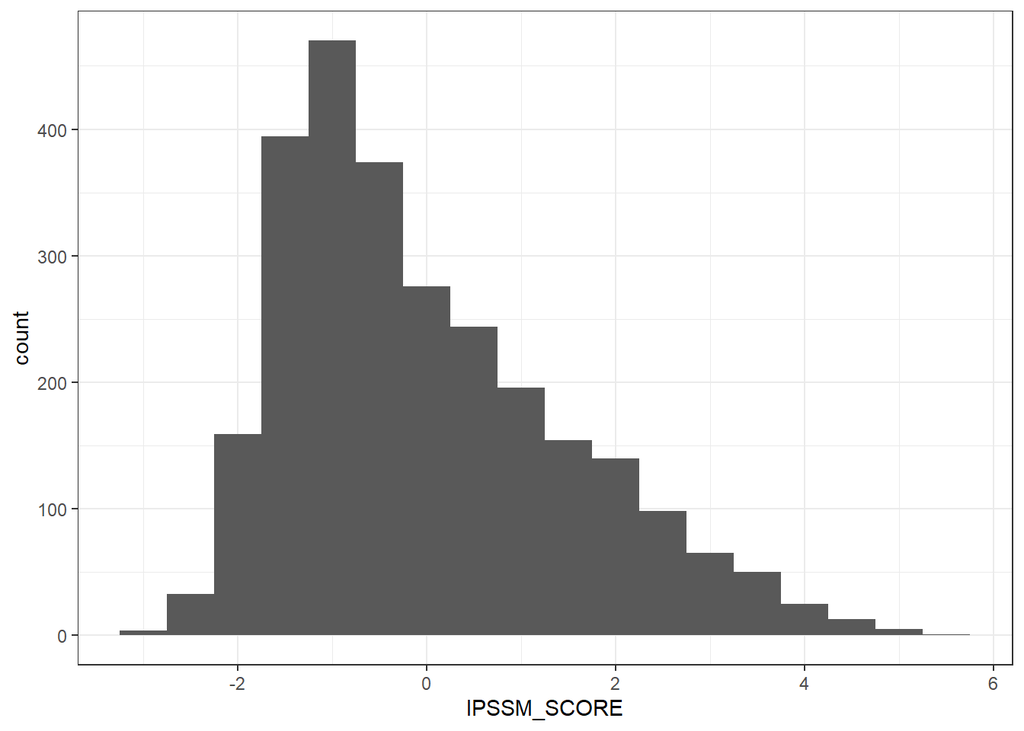

```r
plot_continuous("IPSSM_SCORE", 0.5)
```

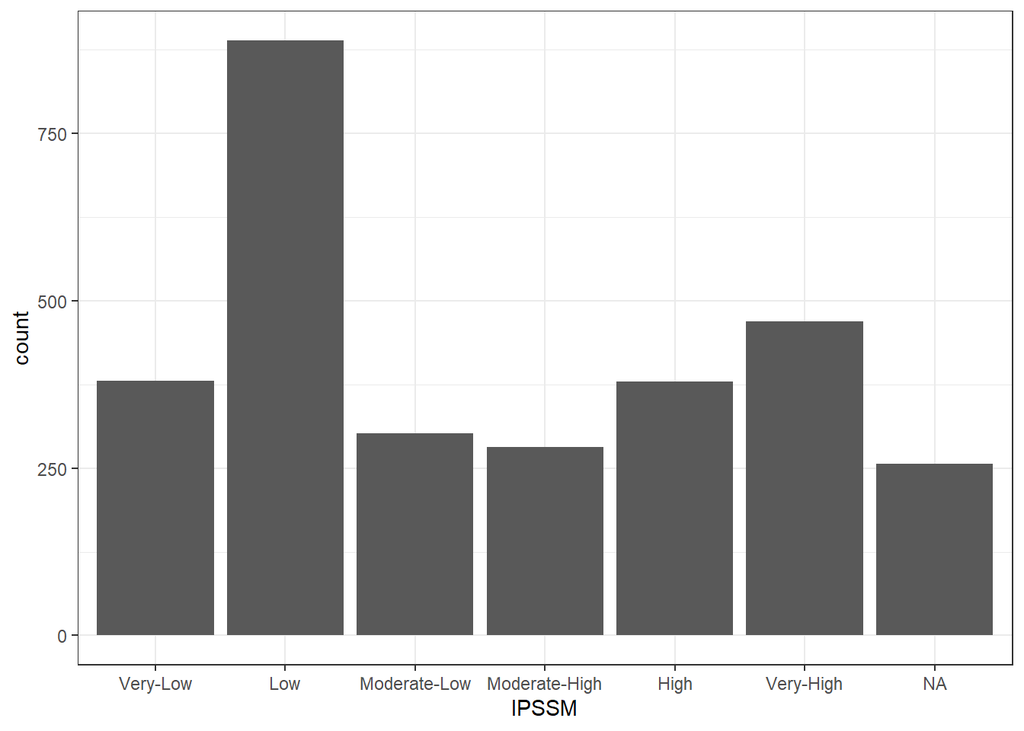

```r
plot_categorical("IPSSM")
```

```r
descrip_categorical("IPSSM")
```

```
## # A tibble: 7 × 3
##   IPSSM             n  perc
##   <fct>         <int> <dbl>
## 1 Very-Low        381  12.9
## 2 Low             889  30.1
## 3 Moderate-Low    302  10.2
## 4 Moderate-High   281   9.5
## 5 High            379  12.8
## 6 Very-High       469  15.9
## 7 <NA>            256   8.7
```

The IPSSM scores show also negative values, reflecting individuals with lower risk than expected. Nonetheless, it still biased to low risk individuals.

## Outcomes

```r
outcomes <- c("OS_YEARS", "OS_STATUS", "AMLt_YEARS", "AMLt_STATUS", "LFS_YEARS", "LFS_STATUS" )
```

### Overall Survival

```r
os_surv <- survfit(Surv(OS_YEARS,OS_STATUS) ~ 1, clinical_all)
print(os_surv)
```

```
## Call: survfit(formula = Surv(OS_YEARS, OS_STATUS) ~ 1, data = clinical_all)
##
##    146 observations deleted due to missingness
##         n events median 0.95LCL 0.95UCL
## [1,] 2811   1354   3.55    3.29    3.88
```

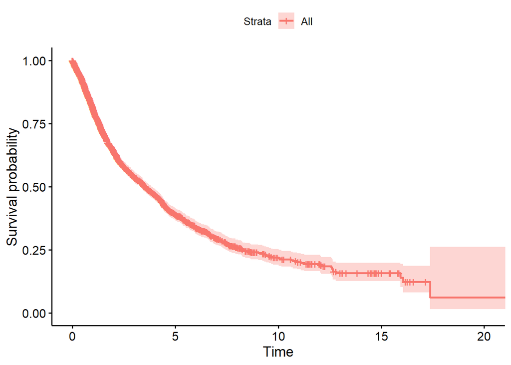

```r
ggsurvplot(os_surv, data = clinical_all)
```

### Acute Myeloid Leukemia transformation;

```r
aml_surv <- survfit(Surv(AMLt_YEARS,AMLt_STATUS) ~ 1, clinical_all)
print(aml_surv)
```

```
## Call: survfit(formula = Surv(AMLt_YEARS, AMLt_STATUS) ~ 1, data = clinical_all)
##
##    324 observations deleted due to missingness
##         n events median 0.95LCL 0.95UCL
## [1,] 2633    415     NA      NA      NA
```

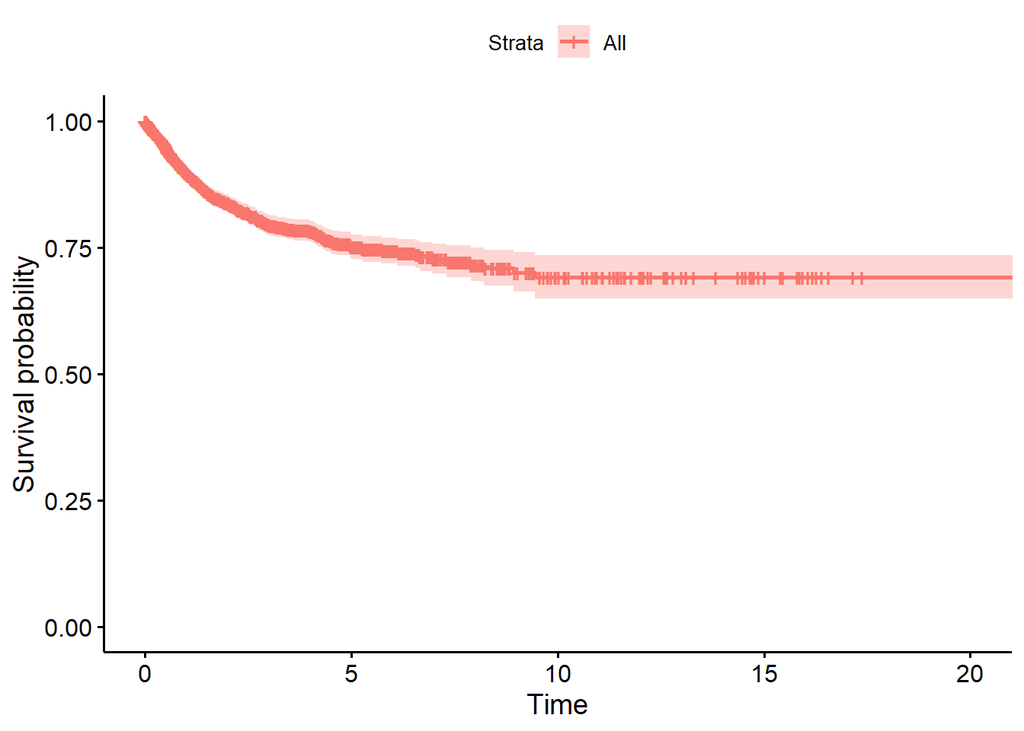

```r
ggsurvplot(aml_surv, data = clinical_all)
```

A small proportion of patients developed Acute Myeloid Leukemia transformation. Transformation happened relative early.

### Leukemia-Free Survival

```r
lfs_surv <- survfit(Surv(LFS_YEARS,LFS_STATUS) ~ 1, clinical_all)
print(lfs_surv)
```

```
## Call: survfit(formula = Surv(LFS_YEARS, LFS_STATUS) ~ 1, data = clinical_all)
##
##    341 observations deleted due to missingness
##         n events median 0.95LCL 0.95UCL
## [1,] 2616   1352   2.91    2.67    3.27
```

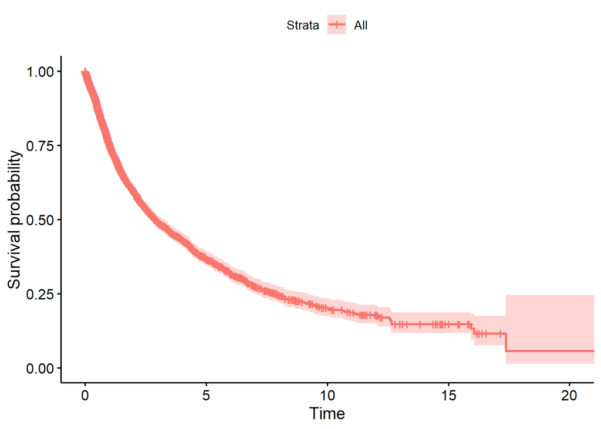

```r
ggsurvplot(lfs_surv, data = clinical_all)
```

A similar proportion of patients that died developed leukemia. The decrease is sharper and peaks around 3 years after starting the follow-up.

## Treatments

```r
treatments <- c("hma", "lenalidomid", "chemotherapy", "transplant")
```

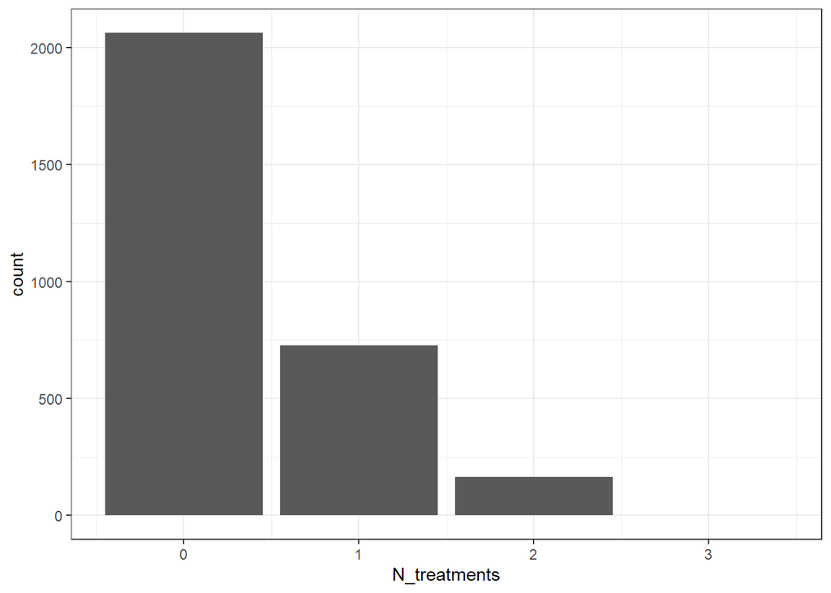

```r
clinical_all <- clinical_all %>%
  mutate(N_treatments = hma + lenalidomid + chemotherapy + transplant)


plot_categorical("N_treatments")
```

```r
descrip_categorical("N_treatments")
```

```
## # A tibble: 4 × 3
##   N_treatments     n  perc
##          <dbl> <int> <dbl>
## 1            0  2063  69.8
## 2            1   728  24.6
## 3            2   164   5.5
## 4            3     2   0.1
```

Most patients did not have any treatment. Of the patients treated, most have just one treatment.

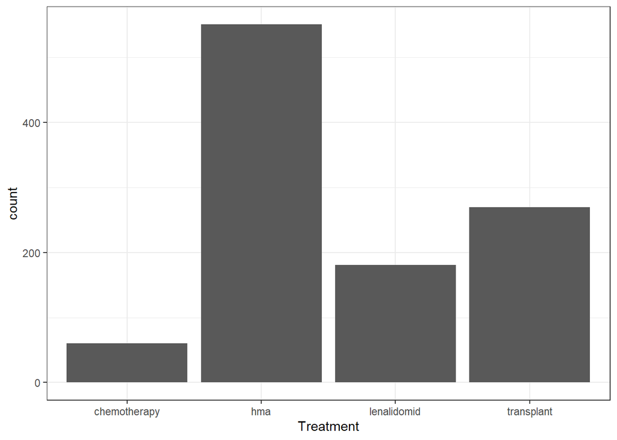

```r
clin_sum <- clinical_all %>%
  select(hma, lenalidomid, chemotherapy, transplant) %>%
  gather(Treatment, Value) %>%
  filter(Value != 0)

ggplot(clin_sum, aes(x = Treatment)) +
    geom_bar() +
  theme_bw()
```

```r
clin_sum %>%
  count(Treatment)
```

```
## # A tibble: 4 × 2
##   Treatment        n
##   <chr>        <int>
## 1 chemotherapy    60
## 2 hma            551
## 3 lenalidomid    181
## 4 transplant     270
```

The most frequent treatment was hypomethylation agents (hma).

# Variables covariation

## Demographic vs clinical

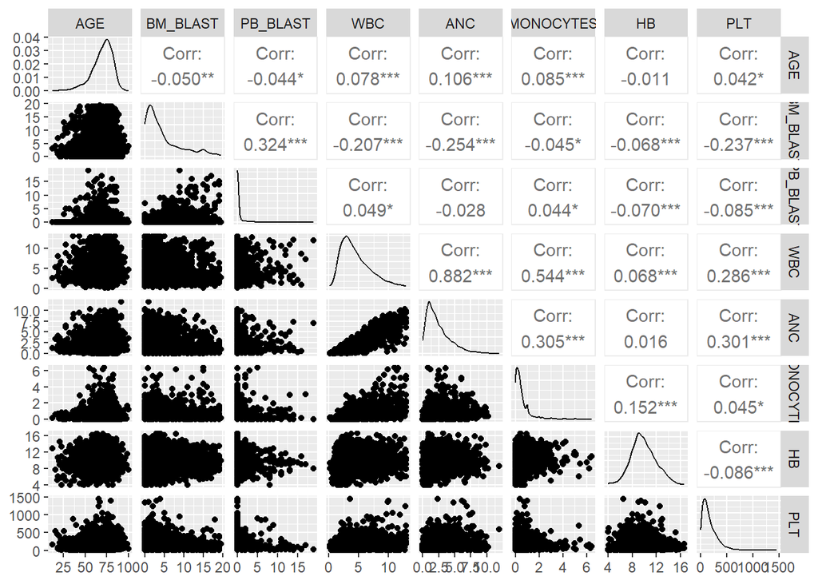

```r
ggpairs(clinical_all[, c("AGE", clin_vars)])
```

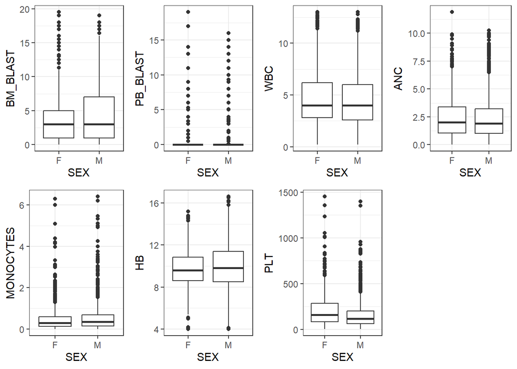

```r
plot_grid(plotlist =
            lapply(clin_vars, function(var){
   ggplot(clinical_all, aes(x = SEX, y = .data[[var]])) +
    geom_boxplot() +
    theme_bw()
}), nrow = 2)
```

```r
summary(lm(PLT ~ SEX, clinical_all))
```

```
##
## Call:
## lm(formula = PLT ~ SEX, data = clinical_all)
##
## Residuals:
##     Min      1Q  Median      3Q     Max
## -197.32  -99.32  -38.32   62.68 1248.68
##
## Coefficients:
##             Estimate Std. Error t value Pr(>|t|)
## (Intercept)  202.325      4.368  46.322   <2e-16 ***
## SEXM         -50.690      5.643  -8.983   <2e-16 ***
## ---
## Signif. codes:  0 '***' 0.001 '**' 0.01 '*' 0.05 '.' 0.1 ' ' 1
##
## Residual standard error: 147.3 on 2837 degrees of freedom
##   (118 observations deleted due to missingness)
## Multiple R-squared:  0.02766,    Adjusted R-squared:  0.02732
## F-statistic:  80.7 on 1 and 2837 DF,  p-value: < 2.2e-16
```

## Demographic vs cytogenetics

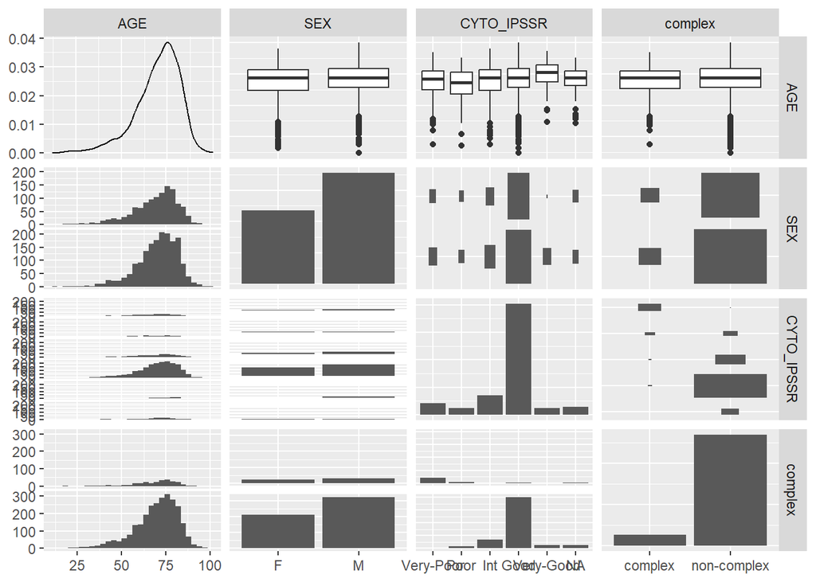

```r
ggpairs(clinical_all[, c(demo_vars, "CYTO_IPSSR", "complex")])
```

There is no correlation between age and sex and cytogenetics.

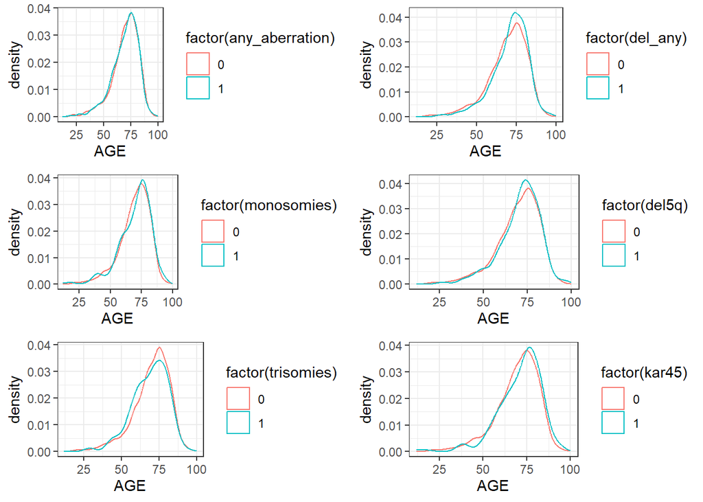

```r
plot_grid(plotlist =
            lapply(top_kar[1:6], function(var){
   ggplot(clinical_all, aes(color = factor(.data[[var]]), x = AGE)) +
    geom_density() +
    theme_bw()
}), nrow = 3)
```

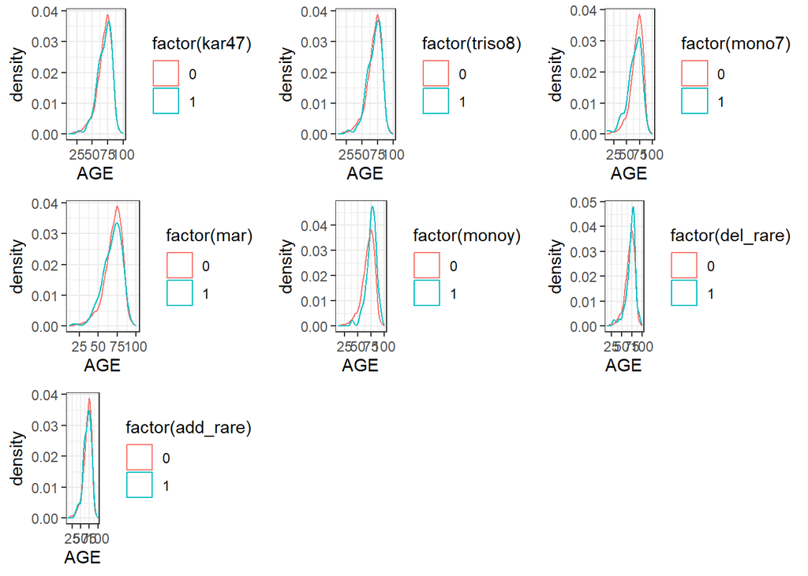

```r
plot_grid(plotlist =
            lapply(top_kar[7:13], function(var){
   ggplot(clinical_all, aes(color = factor(.data[[var]]), x = AGE)) +
    geom_density() +
    theme_bw()
}), nrow = 3)
```

```r
summary(glm(mono7 ~ AGE, clinical_all, family = "binomial" ))
```

```
##
## Call:
## glm(formula = mono7 ~ AGE, family = "binomial", data = clinical_all)
##
## Deviance Residuals:
##     Min       1Q   Median       3Q      Max
## -0.5726  -0.3062  -0.2714  -0.2504   2.7267
##
## Coefficients:
##              Estimate Std. Error z value Pr(>|z|)
## (Intercept) -1.287771   0.435368  -2.958   0.0031 **
## AGE         -0.027331   0.006495  -4.208 2.58e-05 ***
## ---
## Signif. codes:  0 '***' 0.001 '**' 0.01 '*' 0.05 '.' 0.1 ' ' 1
##
## (Dispersion parameter for binomial family taken to be 1)
##
##     Null deviance: 1015.1  on 2936  degrees of freedom
## Residual deviance:  998.9  on 2935  degrees of freedom
##   (20 observations deleted due to missingness)
## AIC: 1002.9
##
## Number of Fisher Scoring iterations: 6
```

```r
summary(glm(monoy ~ AGE, clinical_all, family = "binomial" ))
```

```
##
## Call:
## glm(formula = monoy ~ AGE, family = "binomial", data = clinical_all)
##
## Deviance Residuals:
##     Min       1Q   Median       3Q      Max
## -0.5608  -0.3241  -0.2709  -0.2149   3.1517
##
## Coefficients:
##             Estimate Std. Error z value Pr(>|z|)
## (Intercept) -6.99891    0.76669  -9.129  < 2e-16 ***
## AGE          0.05229    0.01010   5.179 2.23e-07 ***
## ---
## Signif. codes:  0 '***' 0.001 '**' 0.01 '*' 0.05 '.' 0.1 ' ' 1
##
## (Dispersion parameter for binomial family taken to be 1)
##
##     Null deviance: 977.08  on 2936  degrees of freedom
## Residual deviance: 945.25  on 2935  degrees of freedom
##   (20 observations deleted due to missingness)
## AIC: 949.25
##
## Number of Fisher Scoring iterations: 6
```

```r
summary(glm(del_rare ~ AGE, clinical_all, family = "binomial" ))
```

```
##
## Call:
## glm(formula = del_rare ~ AGE, family = "binomial", data = clinical_all)
##
## Deviance Residuals:
##     Min       1Q   Median       3Q      Max
## -0.3542  -0.2914  -0.2738  -0.2526   2.8514
##
## Coefficients:
##              Estimate Std. Error z value Pr(>|z|)
## (Intercept) -4.557616   0.646543  -7.049  1.8e-12 ***
## AGE          0.018204   0.008865   2.054     0.04 *
## ---
## Signif. codes:  0 '***' 0.001 '**' 0.01 '*' 0.05 '.' 0.1 ' ' 1
##
## (Dispersion parameter for binomial family taken to be 1)
##
##     Null deviance: 925.43  on 2936  degrees of freedom
## Residual deviance: 920.91  on 2935  degrees of freedom
##   (20 observations deleted due to missingness)
## AIC: 924.91
##
## Number of Fisher Scoring iterations: 6
```

```r
summary(glm(any_aberration ~ AGE, clinical_all, family = "binomial" ))
```

```
##
## Call:
## glm(formula = any_aberration ~ AGE, family = "binomial", data = clinical_all)
##
## Deviance Residuals:
##    Min      1Q  Median      3Q     Max
## -1.194  -1.151  -1.139   1.204   1.225
##
## Coefficients:
##              Estimate Std. Error z value Pr(>|z|)
## (Intercept)  0.066730   0.213266   0.313    0.754
## AGE         -0.001805   0.003010  -0.600    0.549
##
## (Dispersion parameter for binomial family taken to be 1)
##
##     Null deviance: 4069.0  on 2936  degrees of freedom
## Residual deviance: 4068.6  on 2935  degrees of freedom
##   (20 observations deleted due to missingness)
## AIC: 4072.6
##
## Number of Fisher Scoring iterations: 3
```

Karyotipic aberrations are not related with age. LOY and rare deletions are increased with older patients while monosomies 7 is associated with younger patients.

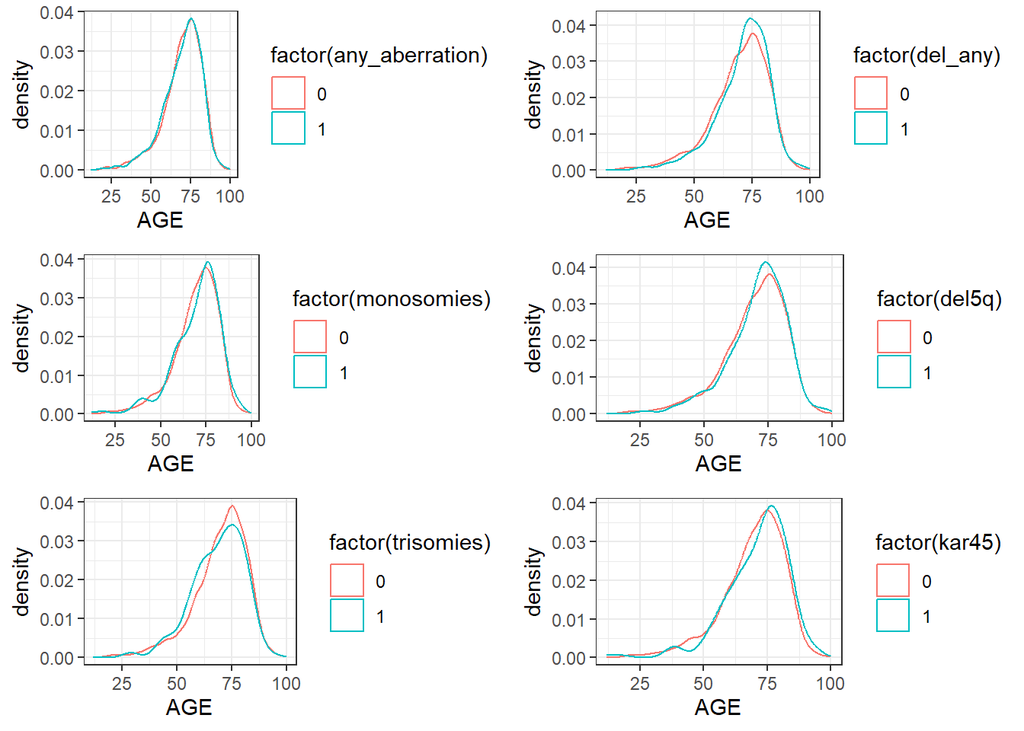

```r
plot_grid(plotlist =
            lapply(top_kar[1:6], function(var){
   ggplot(clinical_all, aes(color = factor(.data[[var]]), x = AGE)) +
    geom_density() +
    theme_bw()
}), nrow = 3)
```

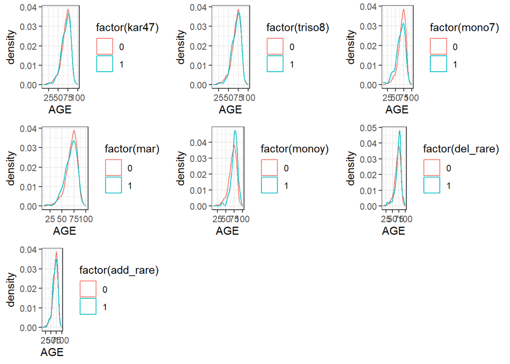

```r
plot_grid(plotlist =
            lapply(top_kar[7:13], function(var){
   ggplot(clinical_all, aes(color = factor(.data[[var]]), x = AGE)) +
    geom_density() +
    theme_bw()
}), nrow = 3)
```

```r
summary(glm(mono7 ~ AGE, clinical_all, family = "binomial" ))
```

```
##
## Call:
## glm(formula = mono7 ~ AGE, family = "binomial", data = clinical_all)
##
## Deviance Residuals:
##     Min       1Q   Median       3Q      Max
## -0.5726  -0.3062  -0.2714  -0.2504   2.7267
##
## Coefficients:
##              Estimate Std. Error z value Pr(>|z|)
## (Intercept) -1.287771   0.435368  -2.958   0.0031 **
## AGE         -0.027331   0.006495  -4.208 2.58e-05 ***
## ---
## Signif. codes:  0 '***' 0.001 '**' 0.01 '*' 0.05 '.' 0.1 ' ' 1
##
## (Dispersion parameter for binomial family taken to be 1)
##
##     Null deviance: 1015.1  on 2936  degrees of freedom
## Residual deviance:  998.9  on 2935  degrees of freedom
##   (20 observations deleted due to missingness)
## AIC: 1002.9
##
## Number of Fisher Scoring iterations: 6
```

```r
summary(glm(monoy ~ AGE, clinical_all, family = "binomial" ))
```

```
##
## Call:
## glm(formula = monoy ~ AGE, family = "binomial", data = clinical_all)
##
## Deviance Residuals:
##     Min       1Q   Median       3Q      Max
## -0.5608  -0.3241  -0.2709  -0.2149   3.1517
##
## Coefficients:
##             Estimate Std. Error z value Pr(>|z|)
## (Intercept) -6.99891    0.76669  -9.129  < 2e-16 ***
## AGE          0.05229    0.01010   5.179 2.23e-07 ***
## ---
## Signif. codes:  0 '***' 0.001 '**' 0.01 '*' 0.05 '.' 0.1 ' ' 1
##
## (Dispersion parameter for binomial family taken to be 1)
##
##     Null deviance: 977.08  on 2936  degrees of freedom
## Residual deviance: 945.25  on 2935  degrees of freedom
##   (20 observations deleted due to missingness)
## AIC: 949.25
##
## Number of Fisher Scoring iterations: 6
```

```r
summary(glm(del_rare ~ AGE, clinical_all, family = "binomial" ))
```

```
##
## Call:
## glm(formula = del_rare ~ AGE, family = "binomial", data = clinical_all)
##
## Deviance Residuals:
##     Min       1Q   Median       3Q      Max
## -0.3542  -0.2914  -0.2738  -0.2526   2.8514
##
## Coefficients:
##              Estimate Std. Error z value Pr(>|z|)
## (Intercept) -4.557616   0.646543  -7.049  1.8e-12 ***
## AGE          0.018204   0.008865   2.054     0.04 *
## ---
## Signif. codes:  0 '***' 0.001 '**' 0.01 '*' 0.05 '.' 0.1 ' ' 1
##
## (Dispersion parameter for binomial family taken to be 1)
##
##     Null deviance: 925.43  on 2936  degrees of freedom
## Residual deviance: 920.91  on 2935  degrees of freedom
##   (20 observations deleted due to missingness)
## AIC: 924.91
##
## Number of Fisher Scoring iterations: 6
```

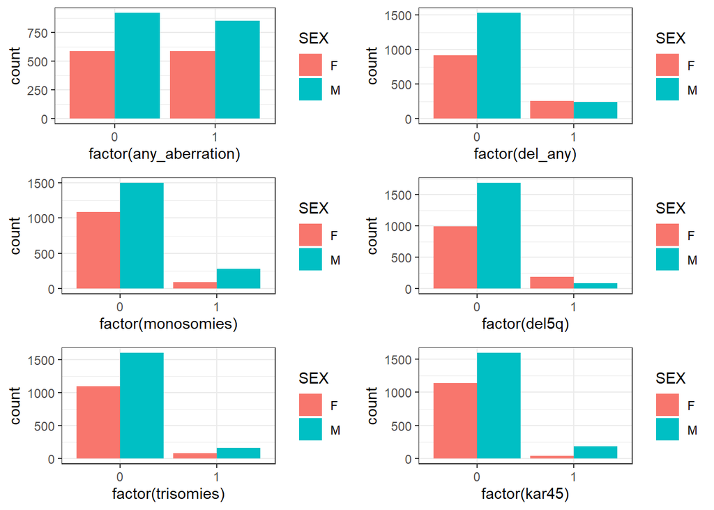

```r
plot_grid(plotlist =
            lapply(top_kar[1:6], function(var){
   ggplot(clinical_all, aes(x = factor(.data[[var]]), fill = SEX)) +
    geom_bar(position = "dodge") +
    theme_bw()
}), nrow = 3)
```

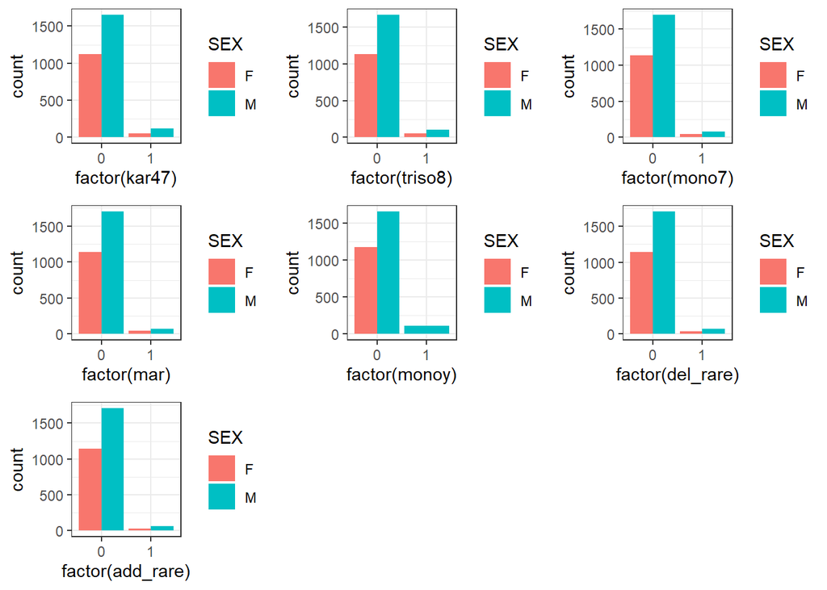

```r
plot_grid(plotlist =
            lapply(top_kar[7:13], function(var){
   ggplot(clinical_all, aes(x = factor(.data[[var]]), fill = SEX)) +
    geom_bar(position = "dodge") +
    theme_bw()
}), nrow = 3)
```

```r
fisher.test(table(clinical_all$del_any, clinical_all$SEX))
```

```
##
##  Fisher's Exact Test for Count Data
##
## data:  table(clinical_all$del_any, clinical_all$SEX)
## p-value = 4.729e-09
## alternative hypothesis: true odds ratio is not equal to 1
## 95 percent confidence interval:
##  0.4608206 0.6840376
## sample estimates:
## odds ratio
##  0.5615052
```

```r
fisher.test(table(clinical_all$monosomies, clinical_all$SEX))
```

```
##
##  Fisher's Exact Test for Count Data
##
## data:  table(clinical_all$monosomies, clinical_all$SEX)
## p-value = 5.45e-10
## alternative hypothesis: true odds ratio is not equal to 1
## 95 percent confidence interval:
##  1.651430 2.742159
## sample estimates:
## odds ratio
##   2.120921
```

```r
fisher.test(table(clinical_all$del5q, clinical_all$SEX))
```

```
##
##  Fisher's Exact Test for Count Data
##
## data:  table(clinical_all$del5q, clinical_all$SEX)
## p-value < 2.2e-16
## alternative hypothesis: true odds ratio is not equal to 1
## 95 percent confidence interval:
##  0.2048573 0.3549838
## sample estimates:
## odds ratio
##  0.2705085
```

```r
fisher.test(table(clinical_all$kar45, clinical_all$SEX))
```

```
##
##  Fisher's Exact Test for Count Data
##
## data:  table(clinical_all$kar45, clinical_all$SEX)
## p-value = 1.308e-11
## alternative hypothesis: true odds ratio is not equal to 1
## 95 percent confidence interval:
##  2.074914 4.173905
## sample estimates:
## odds ratio
##   2.916647
```

Having any type of deletion, specifically del5q is more frequent in women than in men. In contrast, monosomies, specially having 45 chromosomes is more frequent in men, possibly due to LOY.

## Demographic vs CNVs

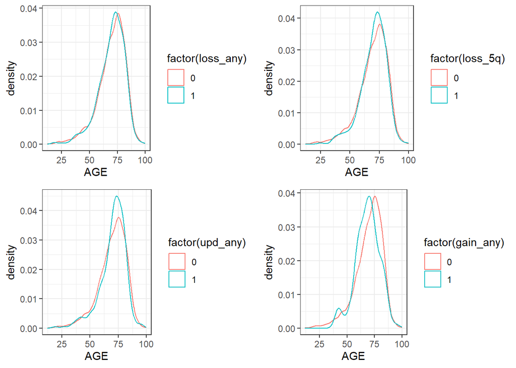

```r
plot_grid(plotlist =
            lapply(top_cnv, function(var){
   ggplot(clinical_all, aes(color = factor(.data[[var]]), x = AGE)) +
    geom_density() +
    theme_bw()
}), nrow = 2)
```

```r
summary(glm(gain_any ~ AGE, clinical_all, family = "binomial" ))
```

```
##
## Call:
## glm(formula = gain_any ~ AGE, family = "binomial", data = clinical_all)
##
## Deviance Residuals:
##     Min       1Q   Median       3Q      Max
## -0.3633  -0.2973  -0.2871  -0.2804   2.5991
##
## Coefficients:
##              Estimate Std. Error z value Pr(>|z|)
## (Intercept) -2.590069   0.503015  -5.149 2.62e-07 ***
## AGE         -0.007925   0.007203  -1.100    0.271
## ---
## Signif. codes:  0 '***' 0.001 '**' 0.01 '*' 0.05 '.' 0.1 ' ' 1
##
## (Dispersion parameter for binomial family taken to be 1)
##
##     Null deviance: 1015.1  on 2936  degrees of freedom
## Residual deviance: 1013.9  on 2935  degrees of freedom
##   (20 observations deleted due to missingness)
## AIC: 1017.9
##
## Number of Fisher Scoring iterations: 6
```

There is no association between any CNV event and age.

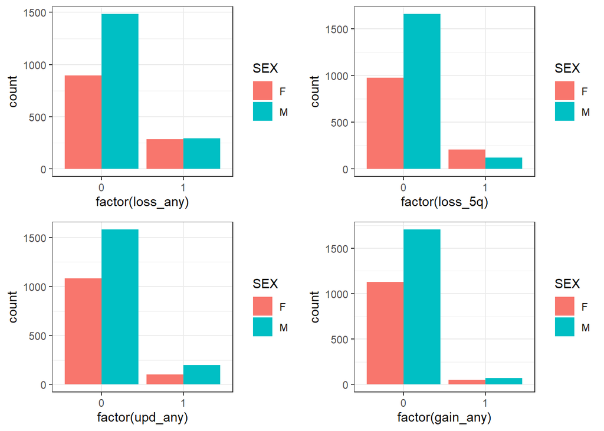

```r
plot_grid(plotlist =
            lapply(top_cnv, function(var){
   ggplot(clinical_all, aes(x = factor(.data[[var]]), fill = SEX)) +
    geom_bar(position = "dodge") +
    theme_bw()
}), nrow = 2)
```

```r
fisher.test(table(clinical_all$loss_any, clinical_all$SEX))
```

```
##
##  Fisher's Exact Test for Count Data
##
## data:  table(clinical_all$loss_any, clinical_all$SEX)
## p-value = 3.03e-07
## alternative hypothesis: true odds ratio is not equal to 1
## 95 percent confidence interval:
##  0.5128545 0.7456156
## sample estimates:
## odds ratio
##  0.6184058
```

```r
fisher.test(table(clinical_all$loss_5q, clinical_all$SEX))
```

```
##
##  Fisher's Exact Test for Count Data
##
## data:  table(clinical_all$loss_5q, clinical_all$SEX)
## p-value < 2.2e-16
## alternative hypothesis: true odds ratio is not equal to 1
## 95 percent confidence interval:
##  0.2673444 0.4364161
## sample estimates:
## odds ratio
##  0.3421383
```

Losses are more frequent in women, specially del5q.

## Demographic vs subtypes

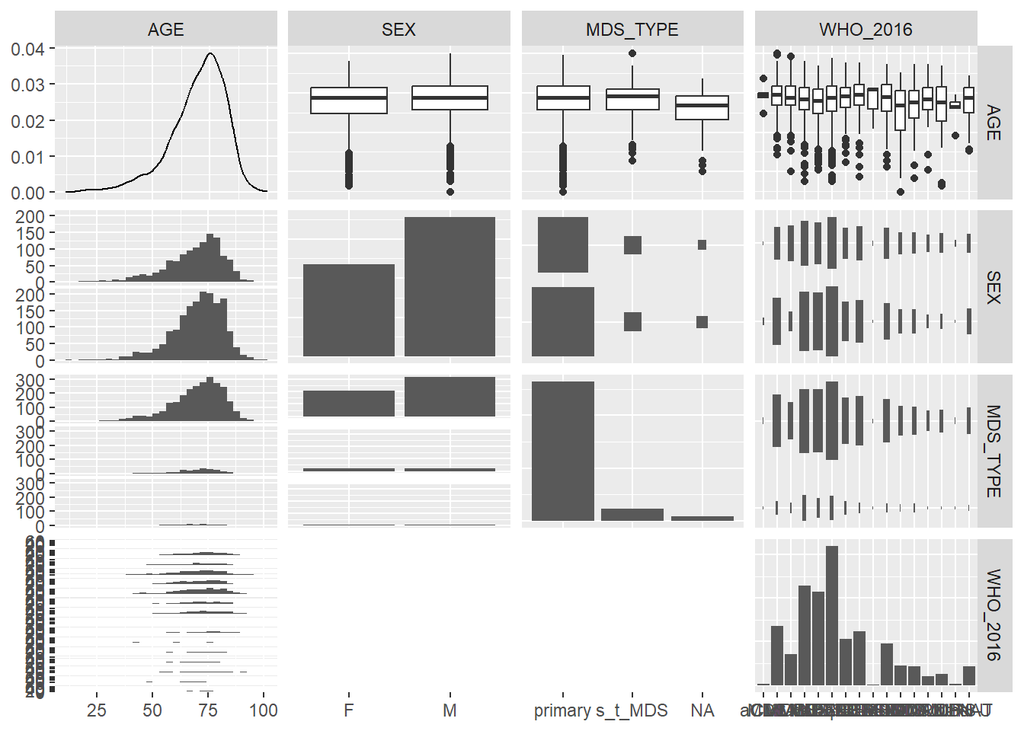

```r
ggpairs(clinical_all[, c(demo_vars, mds_types)])
```

There might be an association between age and WHO subtypes.

## Demographic vs risks

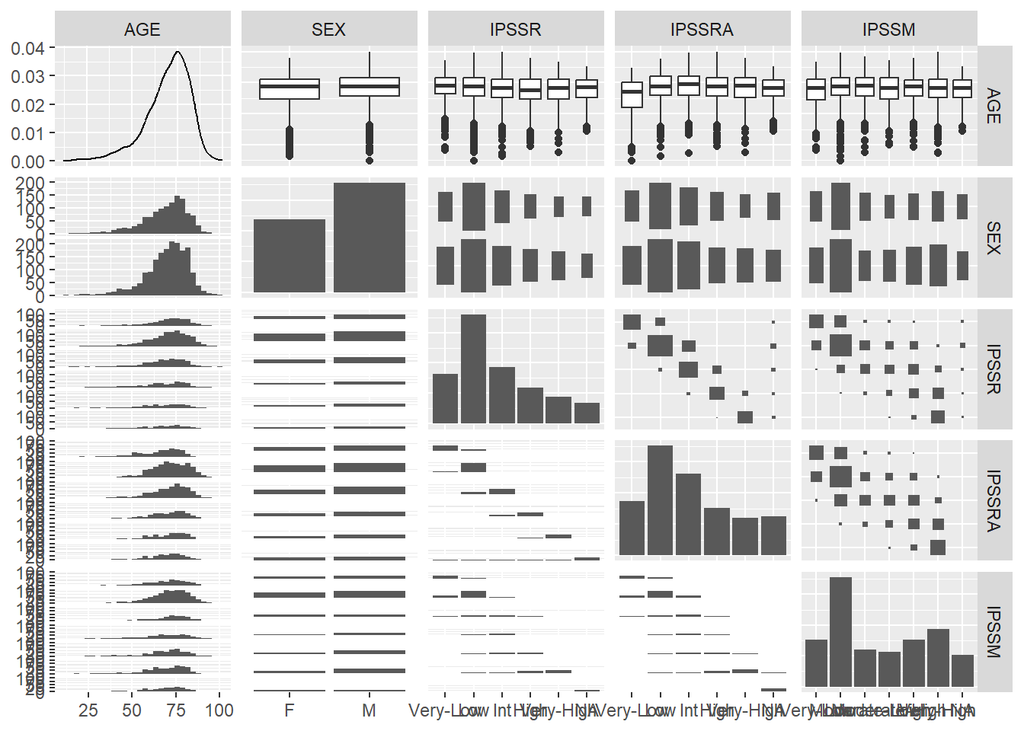

```r
ggpairs(clinical_all[, c(demo_vars, "IPSSR", "IPSSRA", "IPSSM")])
```

There is no association between IPSS categories and sex or age.

## Demographic vs survival

### Overall Survival

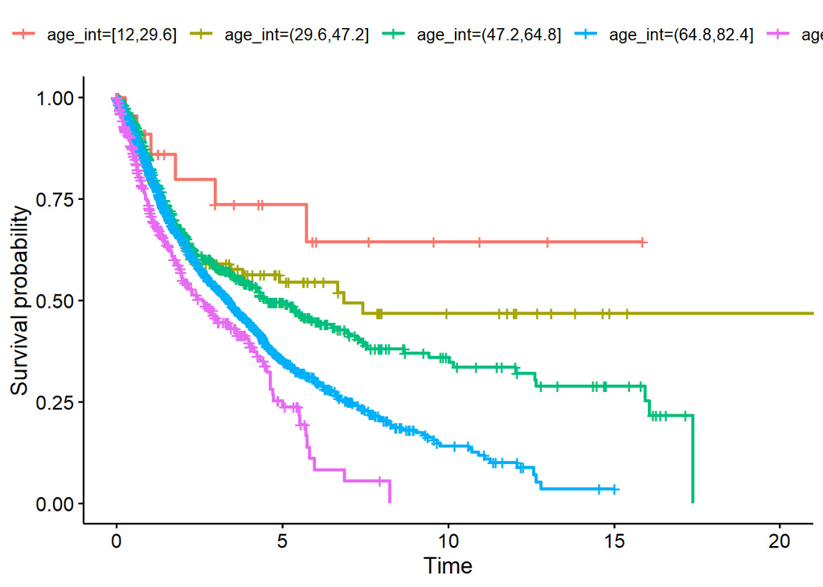

```r
clin_age <- mutate(clinical_all, age_int = cut_interval(AGE, 5))
os_age <- survfit(Surv(OS_YEARS,OS_STATUS) ~ age_int, clin_age)
ggsurvplot(os_age, data = clin_age)
```

```r
coxph(Surv(OS_YEARS,OS_STATUS) ~ AGE, clinical_all)
```

```
## Call:
## coxph(formula = Surv(OS_YEARS, OS_STATUS) ~ AGE, data = clinical_all)
##
##         coef exp(coef) se(coef)     z      p
## AGE 0.021505  1.021738 0.002507 8.578 <2e-16
##
## Likelihood ratio test=80.04  on 1 df, p=< 2.2e-16
## n= 2807, number of events= 1352
##    (150 observations deleted due to missingness)
```

Older patients had worse survival.

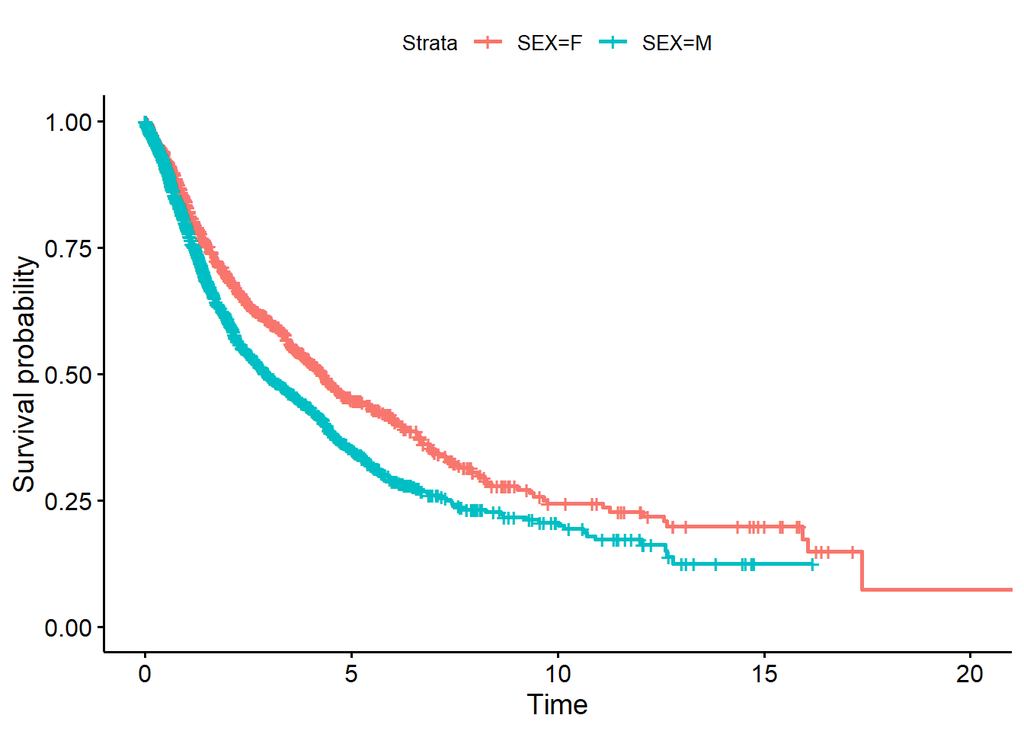

```r
os_sex <- survfit(Surv(OS_YEARS,OS_STATUS) ~ SEX, clinical_all)
ggsurvplot(os_sex, data = clinical_all)
```

```r
coxph(Surv(OS_YEARS,OS_STATUS) ~ SEX, clinical_all)
```

```
## Call:
## coxph(formula = Surv(OS_YEARS, OS_STATUS) ~ SEX, data = clinical_all)
##
##         coef exp(coef) se(coef)     z       p
## SEXM 0.27557   1.31728  0.05656 4.872 1.1e-06
##
## Likelihood ratio test=24.25  on 1 df, p=8.459e-07
## n= 2811, number of events= 1354
##    (146 observations deleted due to missingness)
```

Men had worse survival than women.

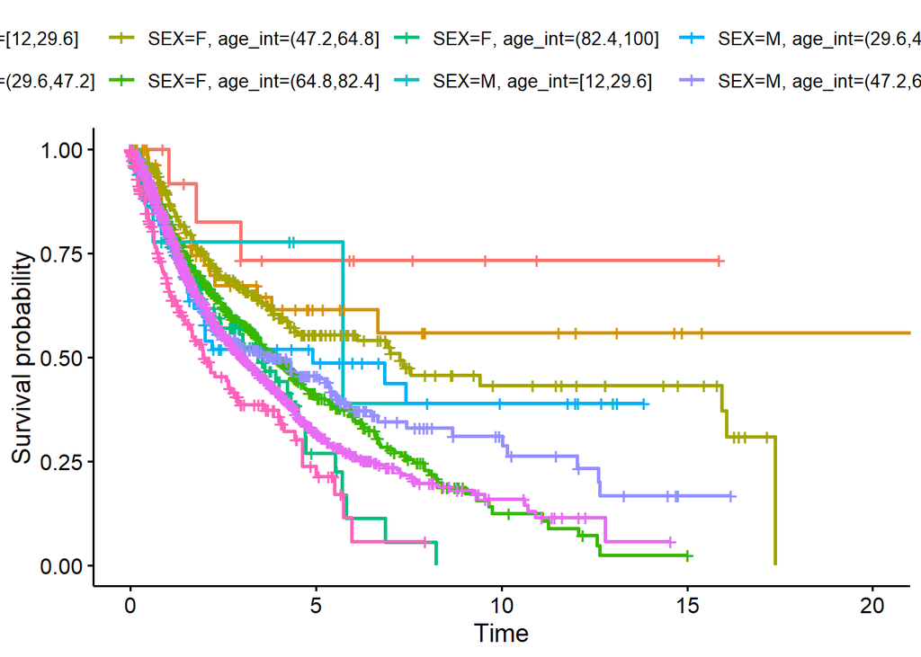

```r
os_demo <- survfit(Surv(OS_YEARS,OS_STATUS) ~ SEX + age_int, clin_age)
ggsurvplot(os_demo, data = clin_age)
```

```r
coxph(Surv(OS_YEARS,OS_STATUS) ~ SEX + AGE, clinical_all)
```

```
## Call:
## coxph(formula = Surv(OS_YEARS, OS_STATUS) ~ SEX + AGE, data = clinical_all)
##
##          coef exp(coef) se(coef)     z        p
## SEXM 0.256025  1.291785 0.056609 4.523 6.11e-06
## AGE  0.021186  1.021412 0.002519 8.411  < 2e-16
##
## Likelihood ratio test=100.9  on 2 df, p=< 2.2e-16
## n= 2807, number of events= 1352
##    (150 observations deleted due to missingness)
```

Women had higher survival at all ages.

### Acute Myeloid Leukemia transformation

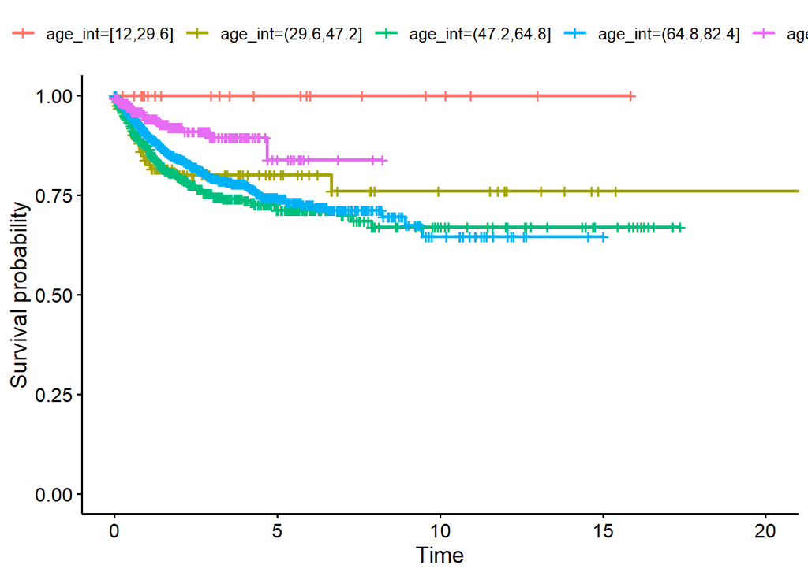

```r
aml_age <- survfit(Surv(AMLt_YEARS,AMLt_STATUS) ~ age_int, clin_age)
ggsurvplot(aml_age, data = clin_age)
```

```r
coxph(Surv(AMLt_YEARS,AMLt_STATUS) ~ AGE, clinical_all)
```

```
## Call:
## coxph(formula = Surv(AMLt_YEARS, AMLt_STATUS) ~ AGE, data = clinical_all)
##
##          coef exp(coef)  se(coef)      z      p
## AGE -0.007902  0.992129  0.003747 -2.109 0.0349
##
## Likelihood ratio test=4.29  on 1 df, p=0.03836
## n= 2632, number of events= 415
##    (325 observations deleted due to missingness)
```

Middle-age patients (47-80 yo) have the highest risk for Acute Myeloid Leukemia transformation.

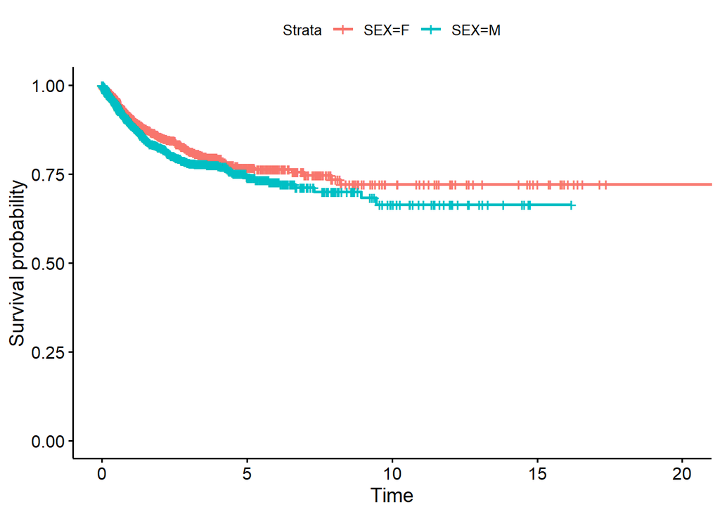

```r
aml_sex <- survfit(Surv(AMLt_YEARS,AMLt_STATUS) ~ SEX, clinical_all)
ggsurvplot(aml_sex, data = clinical_all)
```

```r
coxph(Surv(AMLt_YEARS,AMLt_STATUS) ~ SEX, clinical_all)
```

```
## Call:
## coxph(formula = Surv(AMLt_YEARS, AMLt_STATUS) ~ SEX, data = clinical_all)
##
##        coef exp(coef) se(coef)     z      p
## SEXM 0.1811    1.1986   0.1011 1.792 0.0732
##
## Likelihood ratio test=3.25  on 1 df, p=0.07139
## n= 2633, number of events= 415
##    (324 observations deleted due to missingness)
```

There were no differences between men and women for AML transformation.

### Leukemia-Free Survival

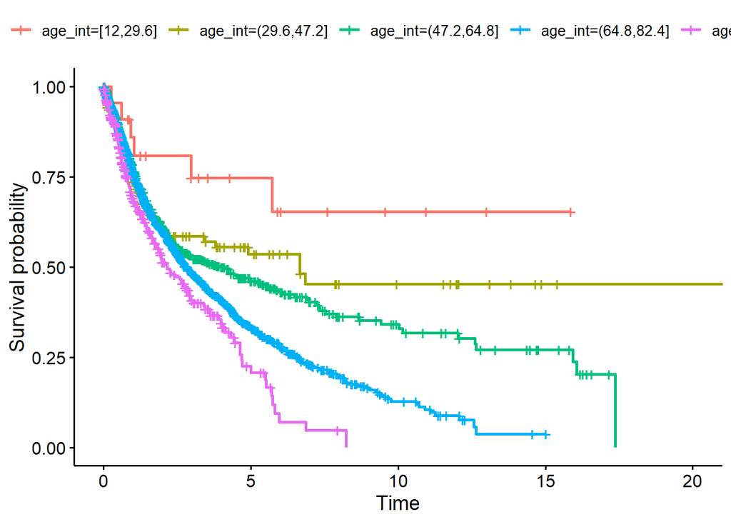

```r
lfs_age <- survfit(Surv(LFS_YEARS,LFS_STATUS) ~ age_int, clin_age)
ggsurvplot(lfs_age, data = clin_age)
```

```r
coxph(Surv(LFS_YEARS,LFS_STATUS) ~ AGE, clinical_all)
```

```
## Call:
## coxph(formula = Surv(LFS_YEARS, LFS_STATUS) ~ AGE, data = clinical_all)
##
##         coef exp(coef) se(coef)     z        p
## AGE 0.018923  1.019103 0.002462 7.685 1.53e-14
##
## Likelihood ratio test=63.86  on 1 df, p=1.334e-15
## n= 2615, number of events= 1351
##    (342 observations deleted due to missingness)
```

Older patients have higher risk for developing leukemia.

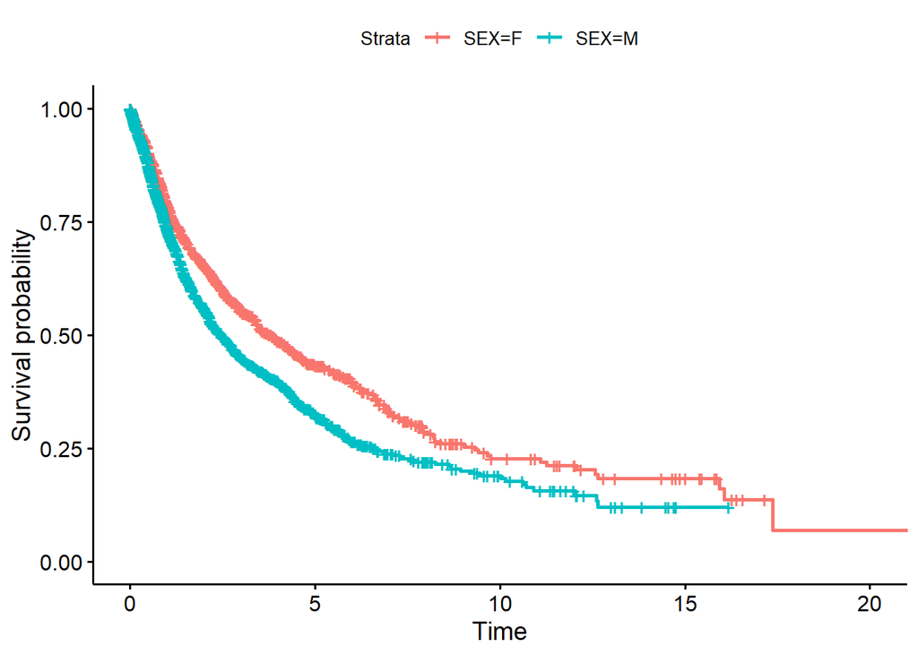

```r
lfs_sex <- survfit(Surv(LFS_YEARS,LFS_STATUS) ~ SEX, clinical_all)
ggsurvplot(lfs_sex, data = clinical_all)
```

```r
coxph(Surv(LFS_YEARS,LFS_STATUS) ~ SEX, clinical_all)
```

```
## Call:
## coxph(formula = Surv(LFS_YEARS, LFS_STATUS) ~ SEX, data = clinical_all)
##
##         coef exp(coef) se(coef)     z        p
## SEXM 0.27616   1.31806  0.05651 4.887 1.02e-06
##
## Likelihood ratio test=24.38  on 1 df, p=7.889e-07
## n= 2616, number of events= 1352
##    (341 observations deleted due to missingness)
```

Men also had higher risk for suffering leukemia.

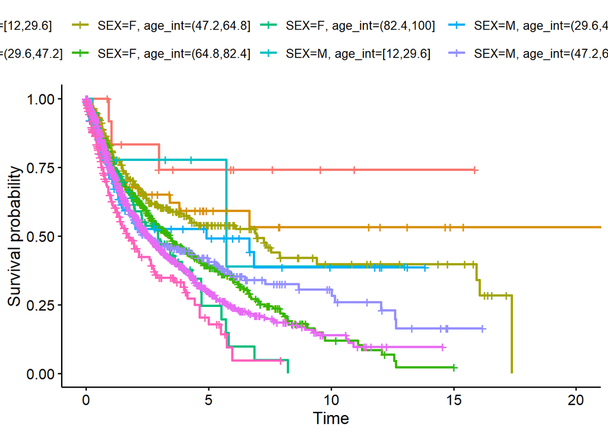

```r
lfs_demo <- survfit(Surv(LFS_YEARS,LFS_STATUS) ~ SEX + age_int, clin_age)
ggsurvplot(lfs_demo, data = clin_age)
```

```r
coxph(Surv(LFS_YEARS,LFS_STATUS) ~ SEX + AGE, clinical_all)
```

```
## Call:
## coxph(formula = Surv(LFS_YEARS, LFS_STATUS) ~ SEX + AGE, data = clinical_all)
##
##          coef exp(coef) se(coef)     z        p
## SEXM 0.257503  1.293695 0.056546 4.554 5.27e-06
## AGE  0.018580  1.018754 0.002475 7.506 6.10e-14
##
## Likelihood ratio test=85.01  on 2 df, p=< 2.2e-16
## n= 2615, number of events= 1351
##    (342 observations deleted due to missingness)
```

The differences between men and women are consistent for all the ages.

## Clinical vs cytogenetics

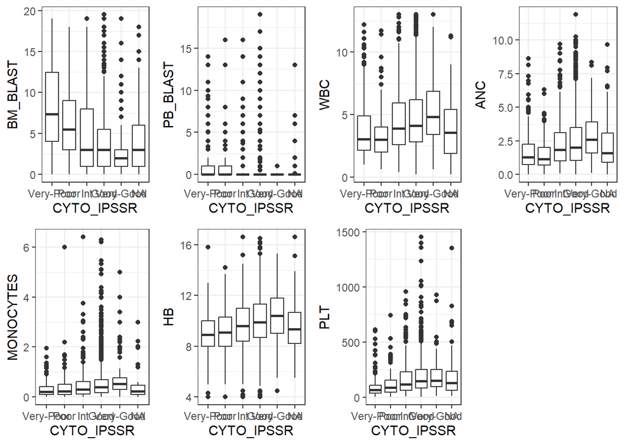

```r
plot_grid(plotlist =
            lapply(clin_vars, function(var){
   ggplot(clinical_all, aes(x = CYTO_IPSSR, y = .data[[var]])) +
    geom_boxplot() +
    theme_bw()
}), nrow = 2)
```

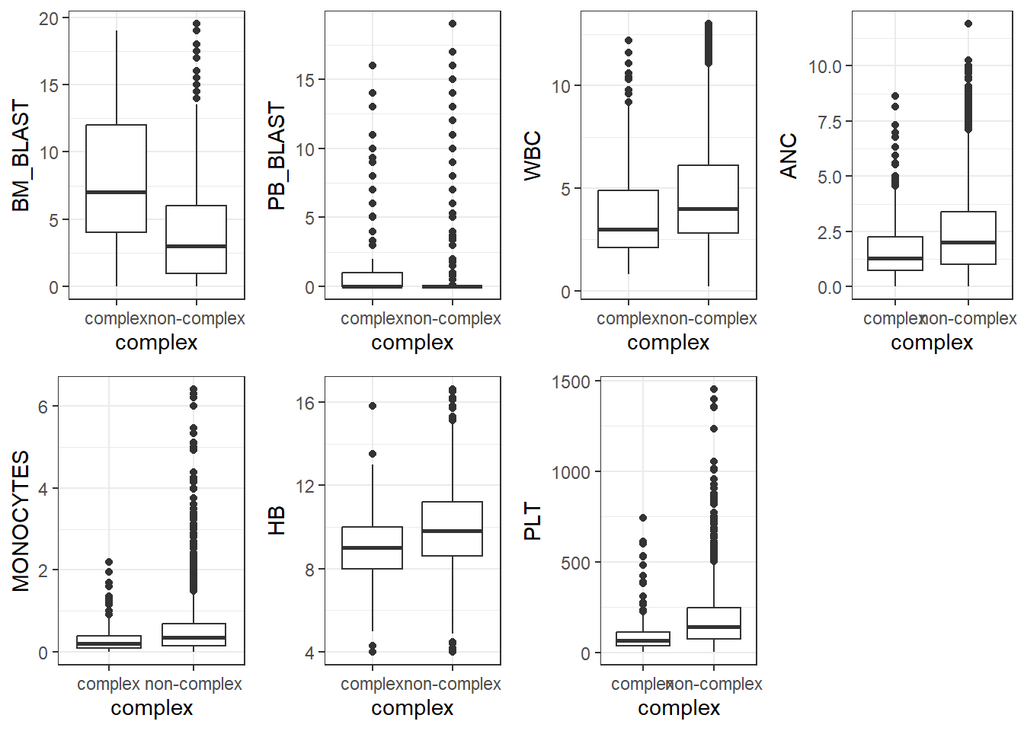

```r
plot_grid(plotlist =
            lapply(clin_vars, function(var){
   ggplot(clinical_all, aes(x = complex, y = .data[[var]])) +
    geom_boxplot() +
    theme_bw()
}), nrow = 2)
```

Cytogenetic measurements were reflected in cell types proportions.

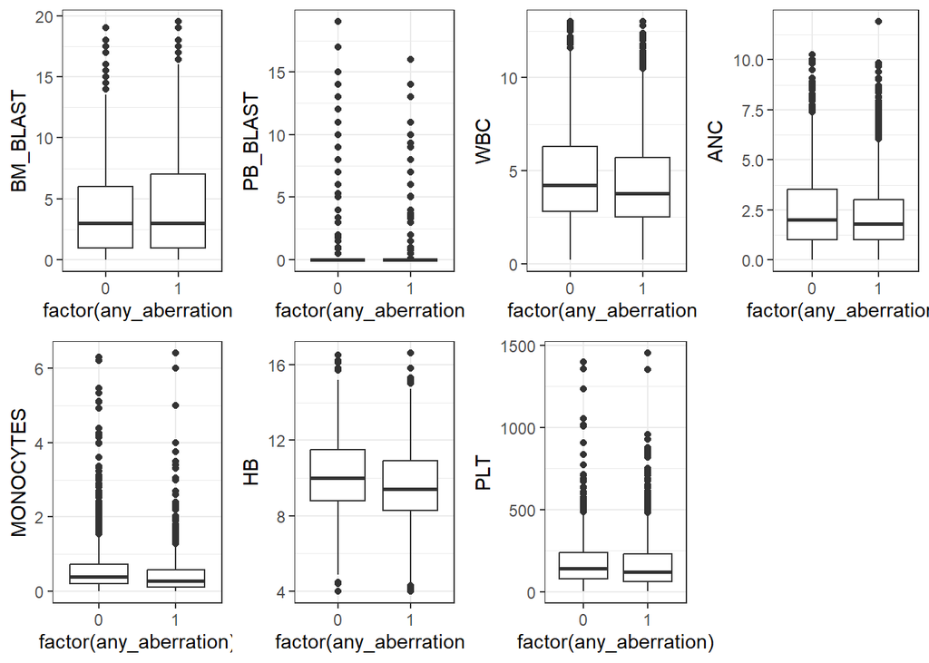

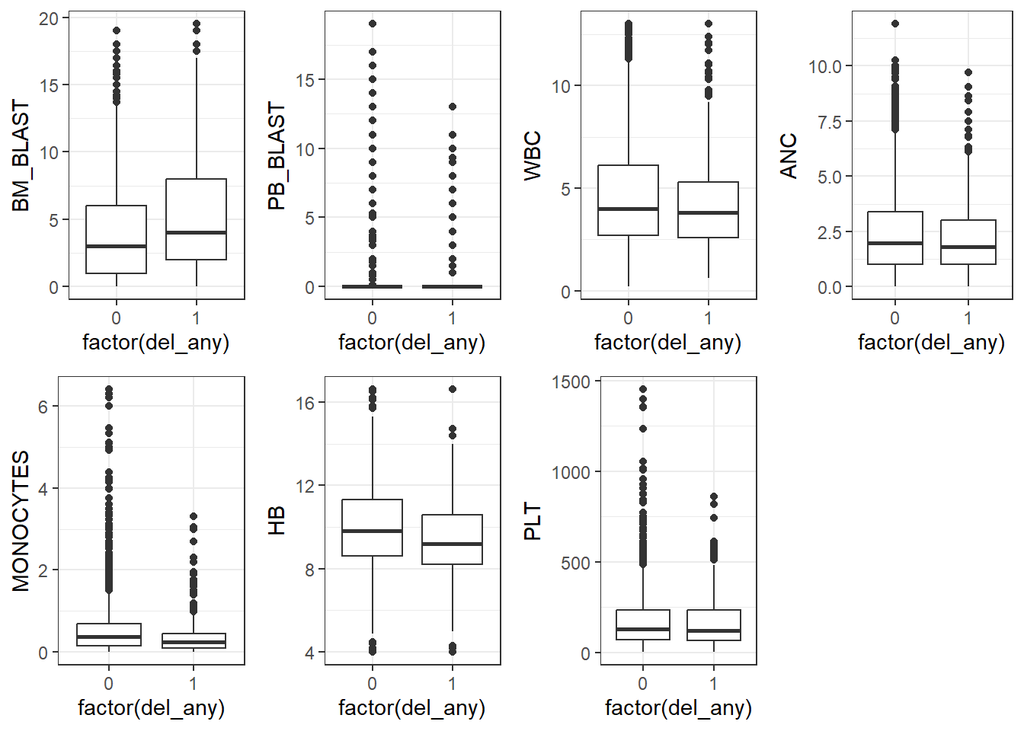

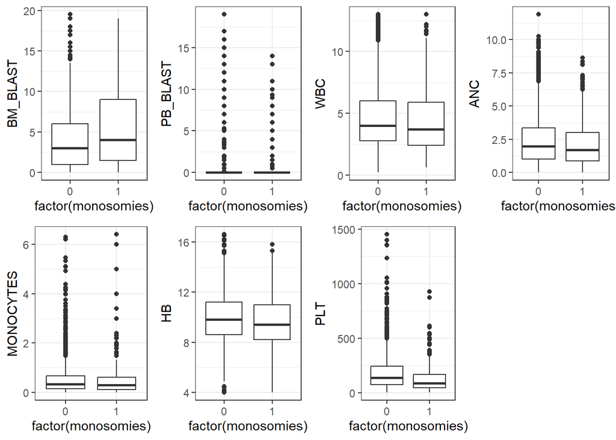

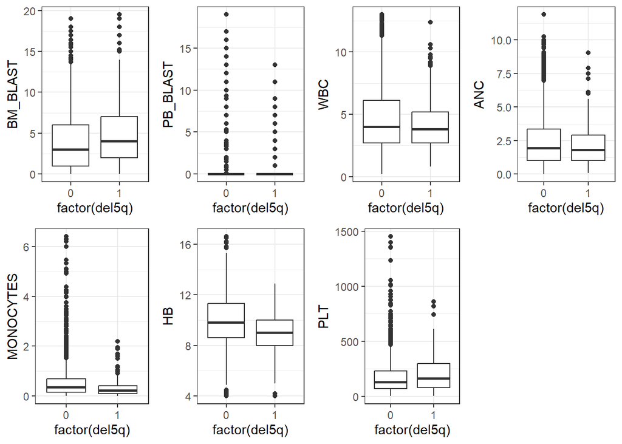

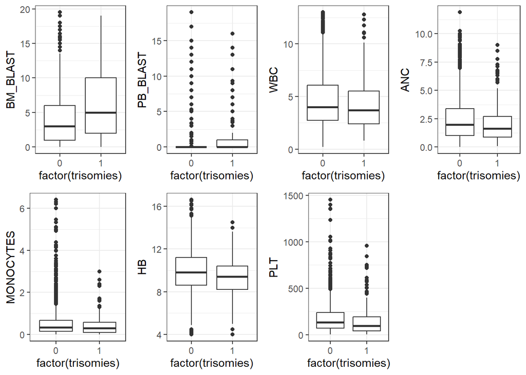

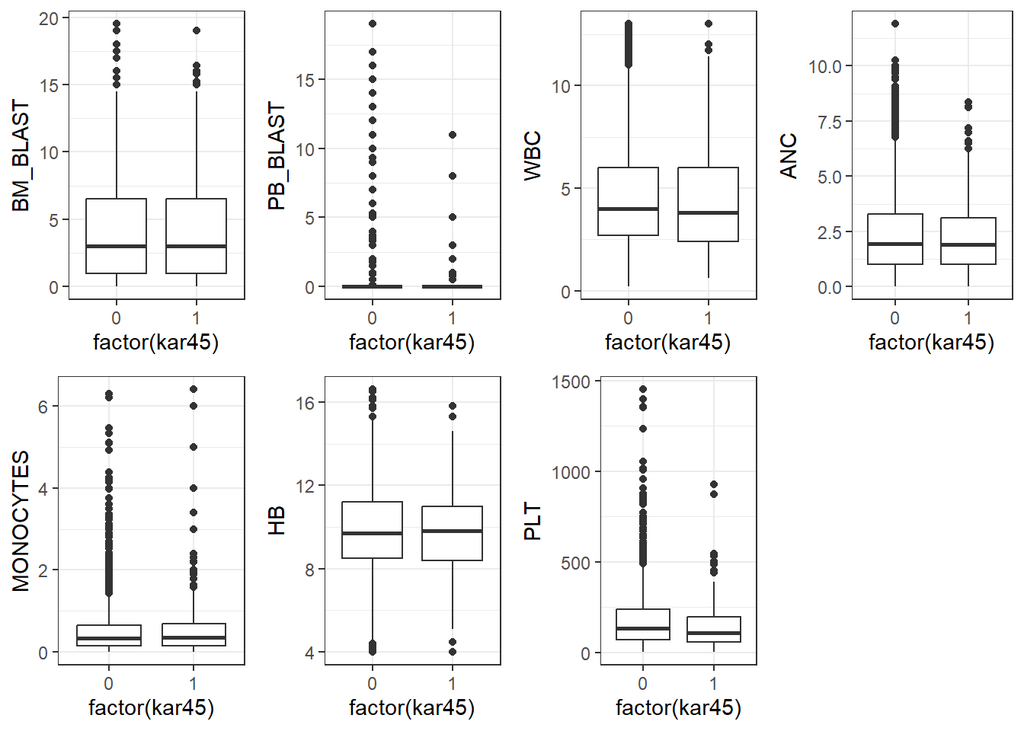

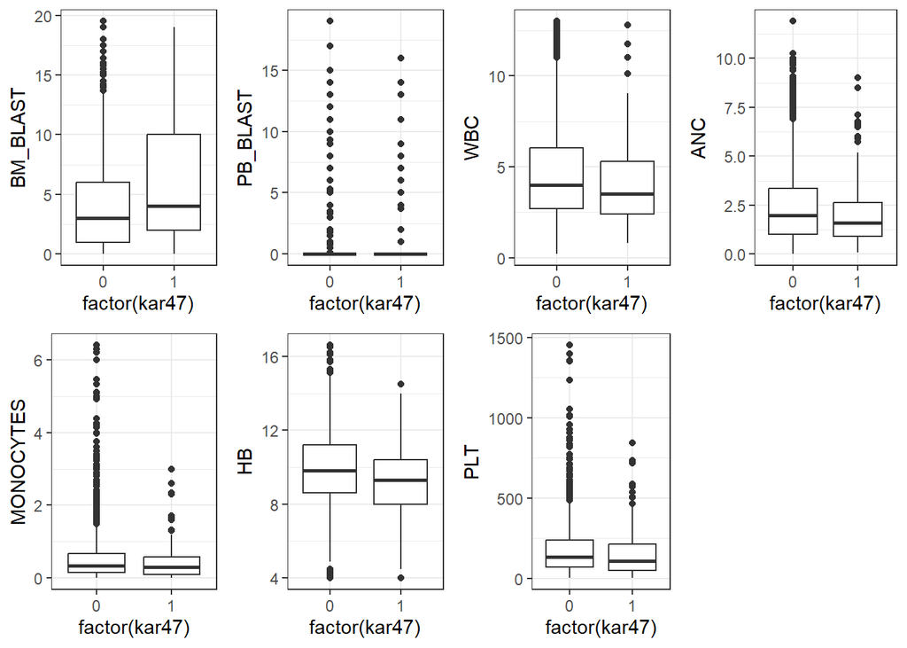

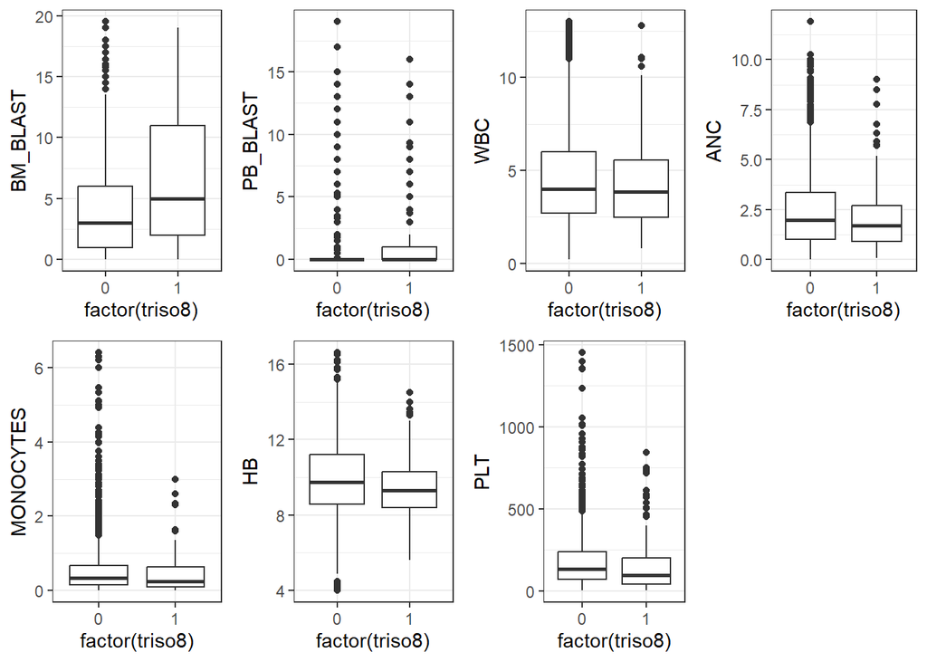

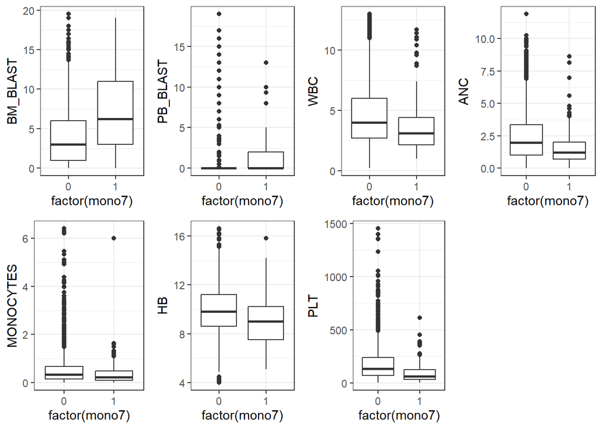

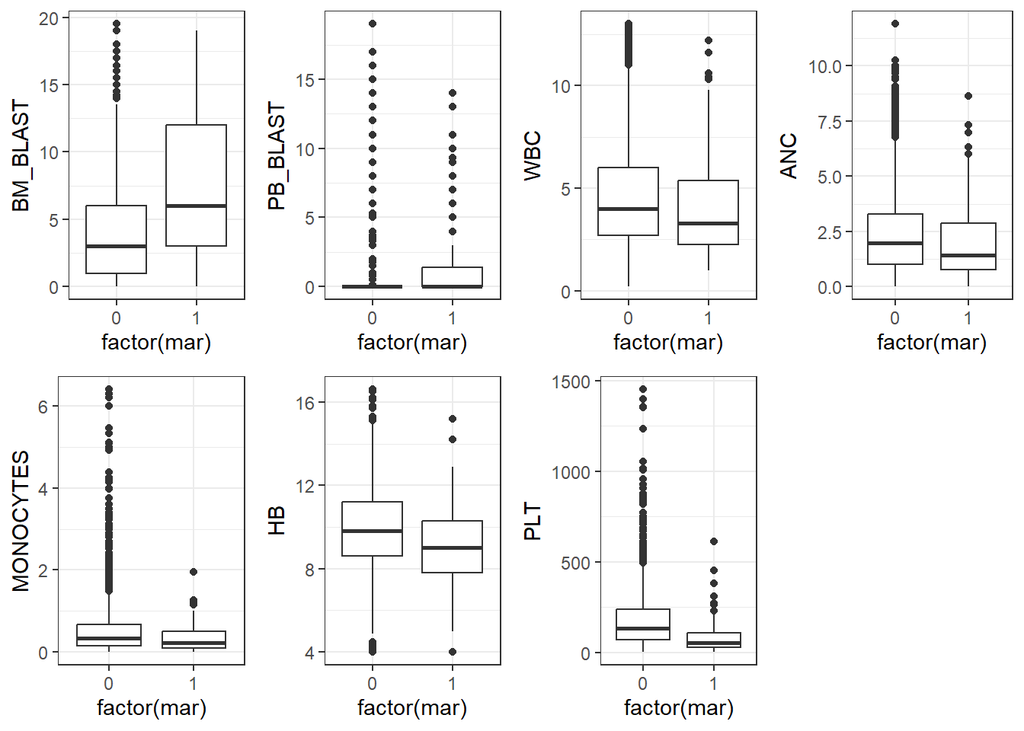

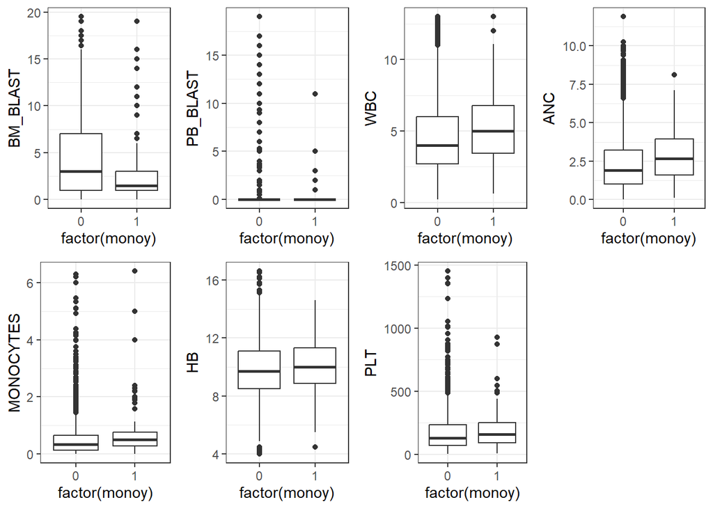

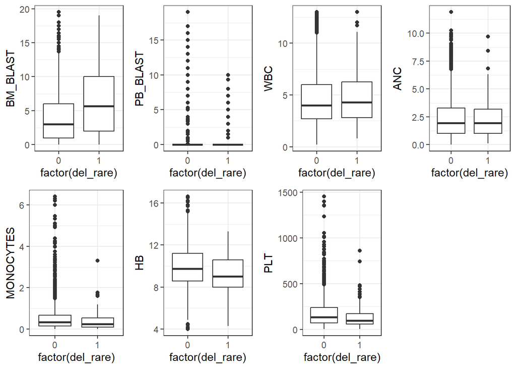

[1 more figures not shown]

```r
lapply(top_kar, function(kar_var){
  plot_grid(plotlist =
            lapply(clin_vars, function(var){
   ggplot(clinical_all, aes(x = factor(.data[[kar_var]]), y = .data[[var]])) +
    geom_boxplot() +
    theme_bw()
  }), nrow = 2)
})
```

Cytogenetic events were reflected in cell types proportions.

## Clinical vs CNVs

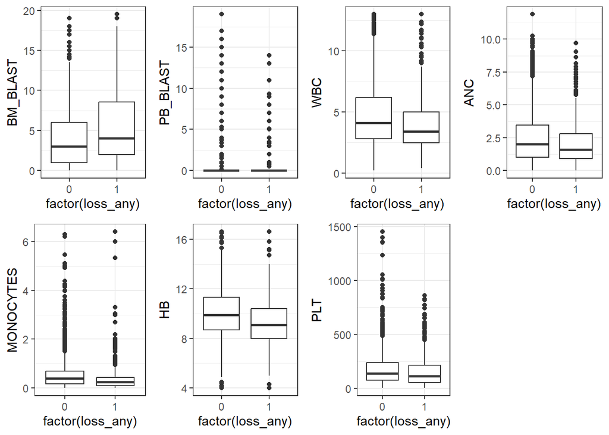

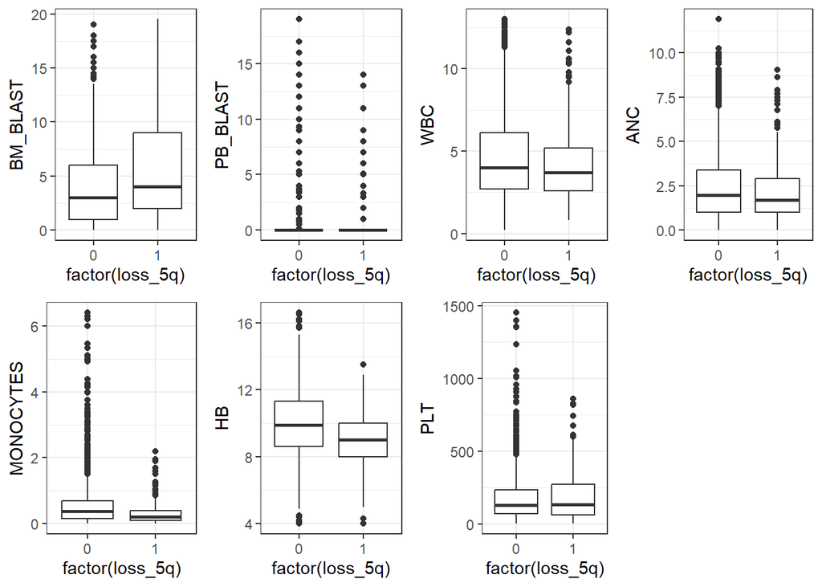

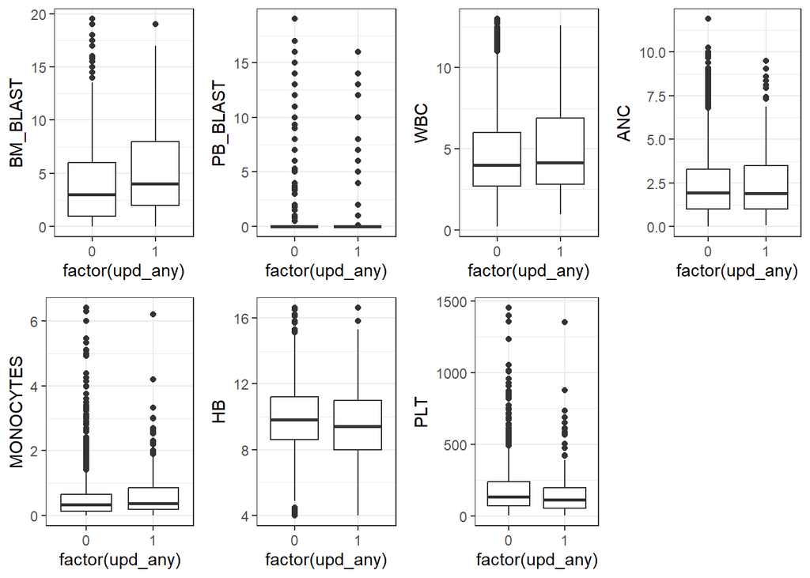

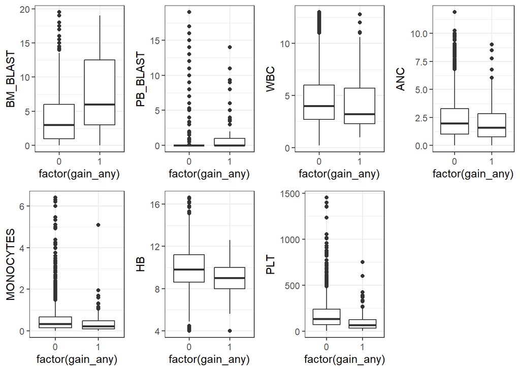

```r
lapply(top_cnv, function(cnv_var){
  plot_grid(plotlist =
            lapply(clin_vars, function(var){
   ggplot(clinical_all, aes(x = factor(.data[[cnv_var]]), y = .data[[var]])) +
    geom_boxplot() +
    theme_bw()
  }), nrow = 2)
})
```

There is an association between top CNV events and clinical variables.

## Clinical vs subtypes

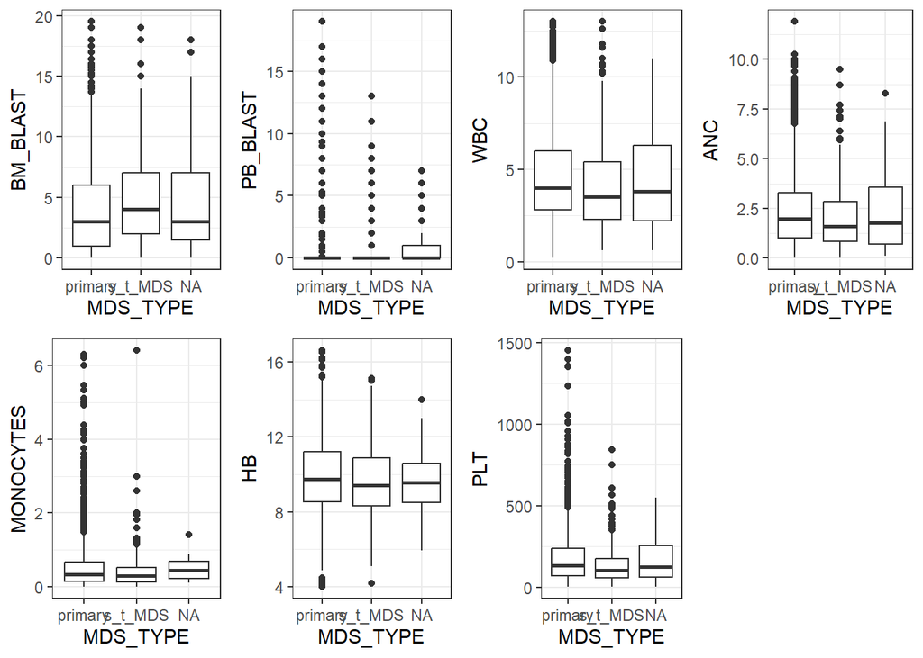

```r
plot_grid(plotlist =
            lapply(clin_vars, function(var){
   ggplot(clinical_all, aes(x = MDS_TYPE, y = .data[[var]])) +
    geom_boxplot() +
    theme_bw()
}), nrow = 2)
```

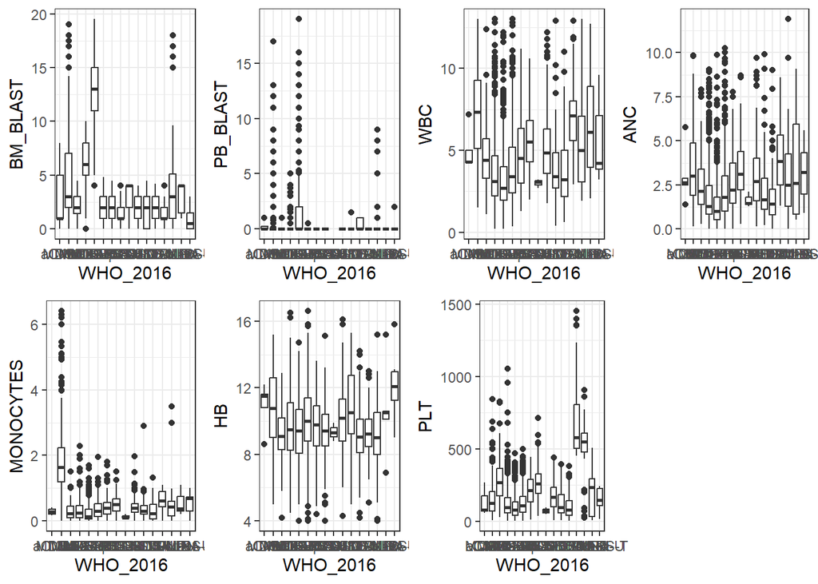

```r
plot_grid(plotlist =
            lapply(clin_vars, function(var){
   ggplot(clinical_all, aes(x = WHO_2016, y = .data[[var]])) +
    geom_boxplot() +
    theme_bw()
}), nrow = 2)
```

There is high correlation between WHO subtypes and clinical variables. Nonetheless, WHO subtypes are defined based on clinical variables.

## Clinical vs risks

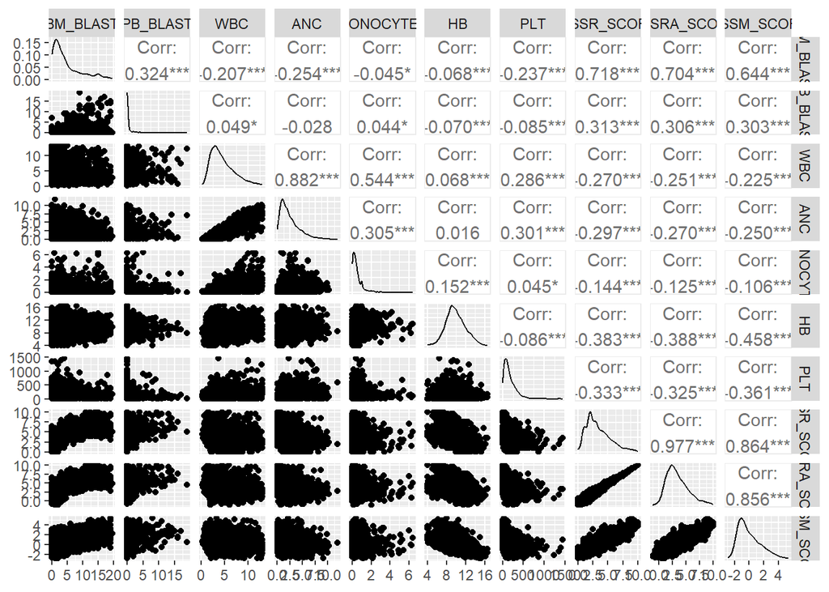

```r
ggpairs(clinical_all[, c(clin_vars, "IPSSR_SCORE", "IPSSRA_SCORE", "IPSSM_SCORE")])
```

Clinical variables are highly correlated with scores.

## Clinical vs Survival

```r
coxph(formula(paste("Surv(OS_YEARS,OS_STATUS) ~",  paste(clin_vars, collapse = "+"))),
              clinical_all)
```

```
## Call:
## coxph(formula = formula(paste("Surv(OS_YEARS,OS_STATUS) ~", paste(clin_vars,
##     collapse = "+"))), data = clinical_all)
##
##                 coef  exp(coef)   se(coef)       z        p
## BM_BLAST   0.0655761  1.0677740  0.0066009   9.934  < 2e-16
## PB_BLAST   0.0689046  1.0713340  0.0158532   4.346 1.38e-05
## WBC        0.0471458  1.0482748  0.0336621   1.401    0.161
## ANC       -0.0544242  0.9470303  0.0422462  -1.288    0.198
## MONOCYTES  0.0467232  1.0478320  0.0637660   0.733    0.464
## HB        -0.1965318  0.8215752  0.0160394 -12.253  < 2e-16
## PLT       -0.0016835  0.9983179  0.0002701  -6.233 4.57e-10
##
## Likelihood ratio test=360  on 7 df, p=< 2.2e-16
## n= 2042, number of events= 982
##    (915 observations deleted due to missingness)
```

Blast proportions, hemoglobin and platelets are associated with overall survival.

```r
coxph(formula(paste("Surv(AMLt_YEARS,AMLt_STATUS) ~",  paste(clin_vars, collapse = "+"))),
              clinical_all)
```

```
## Call:
## coxph(formula = formula(paste("Surv(AMLt_YEARS,AMLt_STATUS) ~",
##     paste(clin_vars, collapse = "+"))), data = clinical_all)
##
##                 coef  exp(coef)   se(coef)      z        p
## BM_BLAST   0.1372756  1.1471442  0.0106043 12.945  < 2e-16
## PB_BLAST   0.0241463  1.0244402  0.0271943  0.888  0.37459
## WBC        0.2276128  1.2555990  0.0499293  4.559 5.15e-06
## ANC       -0.3816500  0.6827339  0.0758677 -5.030 4.89e-07
## MONOCYTES -0.2837425  0.7529605  0.1246739 -2.276  0.02285
## HB        -0.0903855  0.9135789  0.0287661 -3.142  0.00168
## PLT       -0.0014913  0.9985098  0.0005244 -2.844  0.00445
##
## Likelihood ratio test=271  on 7 df, p=< 2.2e-16
## n= 1936, number of events= 299
##    (1021 observations deleted due to missingness)
```

Bone marrow blasts, whole blood counts and neutrophil counts are associated with AML transformation.

```r
coxph(formula(paste("Surv(LFS_YEARS,LFS_STATUS) ~",  paste(clin_vars, collapse = "+"))),
              clinical_all)
```

```
## Call:
## coxph(formula = formula(paste("Surv(LFS_YEARS,LFS_STATUS) ~",
##     paste(clin_vars, collapse = "+"))), data = clinical_all)
##
##                 coef  exp(coef)   se(coef)       z        p
## BM_BLAST   0.0808737  1.0842339  0.0065603  12.328  < 2e-16
## PB_BLAST   0.0531316  1.0545684  0.0162758   3.264   0.0011
## WBC        0.0755759  1.0785051  0.0326002   2.318   0.0204
## ANC       -0.0985161  0.9061811  0.0415778  -2.369   0.0178
## MONOCYTES  0.0030428  1.0030475  0.0655159   0.046   0.9630
## HB        -0.1741346  0.8401838  0.0158794 -10.966  < 2e-16
## PLT       -0.0013948  0.9986062  0.0002634  -5.295 1.19e-07
##
## Likelihood ratio test=370.8  on 7 df, p=< 2.2e-16
## n= 1920, number of events= 994
##    (1037 observations deleted due to missingness)
```

Bone marrow proportions, hemoglobin and platelets are associated with leukemia free survival.

## Karyotype vs Survival

### Overall survival

```r
coxph(Surv(OS_YEARS,OS_STATUS) ~ any_aberration, clinical_all)
```

```
## Call:
## coxph(formula = Surv(OS_YEARS, OS_STATUS) ~ any_aberration, data = clinical_all)
##
##                   coef exp(coef) se(coef)     z      p
## any_aberration 0.50094   1.65028  0.05513 9.087 <2e-16
##
## Likelihood ratio test=83.89  on 1 df, p=< 2.2e-16
## n= 2811, number of events= 1354
##    (146 observations deleted due to missingness)
```

Having any karyotype aberration is associated with survival.

```r
any <- c("del_any", "mar", "monosomies", "trisomies")
coxph(formula(paste("Surv(OS_YEARS,OS_STATUS) ~",  paste(any, collapse = "+"))),
              clinical_all)
```

```
## Call:
## coxph(formula = formula(paste("Surv(OS_YEARS,OS_STATUS) ~", paste(any,
##     collapse = "+"))), data = clinical_all)
##
##               coef exp(coef) se(coef)     z        p
## del_any    0.36949   1.44699  0.06735 5.486 4.10e-08
## mar        0.50701   1.66031  0.12792 3.964 7.38e-05
## monosomies 0.60602   1.83313  0.07936 7.637 2.23e-14
## trisomies  0.55053   1.73416  0.08894 6.190 6.02e-10
##
## Likelihood ratio test=170.2  on 4 df, p=< 2.2e-16
## n= 2811, number of events= 1354
##    (146 observations deleted due to missingness)
```

```r
any2 <- c("kar45", "kar47")
coxph(formula(paste("Surv(OS_YEARS,OS_STATUS) ~",  paste(any2, collapse = "+"))),
              clinical_all)
```

```
## Call:
## coxph(formula = formula(paste("Surv(OS_YEARS,OS_STATUS) ~", paste(any2,
##     collapse = "+"))), data = clinical_all)
##
##          coef exp(coef) se(coef)     z        p
## kar45 0.33405   1.39662  0.09686 3.449 0.000563
## kar47 0.52512   1.69067  0.10182 5.157  2.5e-07
##
## Likelihood ratio test=31.86  on 2 df, p=1.21e-07
## n= 2811, number of events= 1354
##    (146 observations deleted due to missingness)
```

Having 45 or 47 chromosomes is also associated with survival.

```r
kar2 <- top_kar[!top_kar %in% c(any, any2, "any_aberration")]
coxph(formula(paste("Surv(OS_YEARS,OS_STATUS) ~",  paste(kar2, collapse = "+"))),
              clinical_all)
```

```
## Call:
## coxph(formula = formula(paste("Surv(OS_YEARS,OS_STATUS) ~", paste(kar2,
##     collapse = "+"))), data = clinical_all)
##
##              coef exp(coef) se(coef)      z        p
## del5q     0.11450   1.12132  0.08836  1.296  0.19503
## triso8    0.64755   1.91086  0.10373  6.243 4.30e-10
## mono7     0.76892   2.15744  0.12282  6.260 3.84e-10
## monoy    -0.07351   0.92913  0.15235 -0.482  0.62945
## del_rare  0.36123   1.43510  0.13581  2.660  0.00782
## add_rare  0.91592   2.49909  0.14241  6.431 1.26e-10
##
## Likelihood ratio test=164.1  on 6 df, p=< 2.2e-16
## n= 2811, number of events= 1354
##    (146 observations deleted due to missingness)
```

Trisomy8, monosomy7 and rare additions are associated with overall survival.

```r
coxph(Surv(OS_YEARS,OS_STATUS) ~ monoy, clinical_all, subset = SEX == "M")
```

```
## Call:
## coxph(formula = Surv(OS_YEARS, OS_STATUS) ~ monoy, data = clinical_all,
##     subset = SEX == "M")
##
##          coef exp(coef) se(coef)      z      p
## monoy -0.2853    0.7518   0.1532 -1.862 0.0626
##
## Likelihood ratio test=3.78  on 1 df, p=0.05194
## n= 1692, number of events= 856
##    (84 observations deleted due to missingness)
```

### Acute Myeloid Leukemia transformation

```r
coxph(Surv(AMLt_YEARS,AMLt_STATUS) ~ any_aberration, clinical_all)
```

```
## Call:
## coxph(formula = Surv(AMLt_YEARS, AMLt_STATUS) ~ any_aberration,
##     data = clinical_all)
##
##                   coef exp(coef) se(coef)     z        p
## any_aberration 0.50952   1.66450  0.09976 5.108 3.26e-07
##
## Likelihood ratio test=26.57  on 1 df, p=2.538e-07
## n= 2633, number of events= 415
##    (324 observations deleted due to missingness)
```

Having any karyotype aberration is associated with AML transformation.

```r
coxph(formula(paste("Surv(AMLt_YEARS,AMLt_STATUS) ~",  paste(any, collapse = "+"))),
              clinical_all)
```

```
## Call:
## coxph(formula = formula(paste("Surv(AMLt_YEARS,AMLt_STATUS) ~",
##     paste(any, collapse = "+"))), data = clinical_all)
##
##               coef exp(coef) se(coef)     z        p
## del_any    0.47060   1.60096  0.11708 4.019 5.83e-05
## mar        0.03422   1.03481  0.23544 0.145    0.884
## monosomies 0.70064   2.01504  0.13707 5.111 3.20e-07
## trisomies  0.78494   2.19228  0.14548 5.396 6.83e-08
##
## Likelihood ratio test=70.53  on 4 df, p=1.757e-14
## n= 2633, number of events= 415
##    (324 observations deleted due to missingness)
```

Having any type of deletion, monosomies or trisomies is associated with AML transformation.

```r
coxph(formula(paste("Surv(AMLt_YEARS,AMLt_STATUS) ~",  paste(any2, collapse = "+"))),
              clinical_all)
```

```
## Call:
## coxph(formula = formula(paste("Surv(AMLt_YEARS,AMLt_STATUS) ~",
##     paste(any2, collapse = "+"))), data = clinical_all)
##
##         coef exp(coef) se(coef)     z        p
## kar45 0.2844    1.3290   0.1776 1.601    0.109
## kar47 0.6701    1.9545   0.1674 4.003 6.26e-05
##
## Likelihood ratio test=15.07  on 2 df, p=0.0005335
## n= 2633, number of events= 415
##    (324 observations deleted due to missingness)
```

Having 47 chromosomes is also associated with AML transformation, but not having 45.

```r
coxph(formula(paste("Surv(AMLt_YEARS,AMLt_STATUS) ~",  paste(kar2, collapse = "+"))),
              clinical_all)
```

```
## Call:
## coxph(formula = formula(paste("Surv(AMLt_YEARS,AMLt_STATUS) ~",
##     paste(kar2, collapse = "+"))), data = clinical_all)
##
##             coef exp(coef) se(coef)      z        p
## del5q     0.3445    1.4113   0.1448  2.379   0.0174
## triso8    0.7686    2.1568   0.1686  4.558 5.16e-06
## mono7     0.7971    2.2192   0.2006  3.974 7.07e-05
## monoy    -0.6107    0.5430   0.3581 -1.705   0.0881
## del_rare  0.1893    1.2083   0.2386  0.793   0.4276
## add_rare  0.9862    2.6811   0.2260  4.364 1.28e-05
##
## Likelihood ratio test=87.91  on 6 df, p=< 2.2e-16
## n= 2633, number of events= 415
##    (324 observations deleted due to missingness)
```

Trisomy8, monosomy7 and rare additions are associated with AML transformation.

```r
coxph(Surv(AMLt_YEARS,AMLt_STATUS) ~ monoy, clinical_all, subset = SEX == "M")
```

```
## Call:
## coxph(formula = Surv(AMLt_YEARS, AMLt_STATUS) ~ monoy, data = clinical_all,
##     subset = SEX == "M")
##
##          coef exp(coef) se(coef)      z      p
## monoy -0.8325    0.4349   0.3593 -2.317 0.0205
##
## Likelihood ratio test=7.05  on 1 df, p=0.007921
## n= 1581, number of events= 256
##    (195 observations deleted due to missingness)
```

### Leukemia-Free Survival

```r
coxph(Surv(LFS_YEARS,LFS_STATUS) ~ any_aberration, clinical_all)
```

```
## Call:
## coxph(formula = Surv(LFS_YEARS, LFS_STATUS) ~ any_aberration,
##     data = clinical_all)
##
##                   coef exp(coef) se(coef)     z      p
## any_aberration 0.47954   1.61534  0.05509 8.704 <2e-16
##
## Likelihood ratio test=76.82  on 1 df, p=< 2.2e-16
## n= 2616, number of events= 1352
##    (341 observations deleted due to missingness)
```

Having any karyotype aberration is associated with Leukemia Free Survival (LFS).

```r
coxph(formula(paste("Surv(LFS_YEARS,LFS_STATUS) ~",  paste(any, collapse = "+"))),
              clinical_all)
```

```
## Call:
## coxph(formula = formula(paste("Surv(LFS_YEARS,LFS_STATUS) ~",
##     paste(any, collapse = "+"))), data = clinical_all)
##
##               coef exp(coef) se(coef)     z        p
## del_any    0.33805   1.40221  0.06792 4.977 6.46e-07
## mar        0.37332   1.45255  0.12924 2.889  0.00387
## monosomies 0.58840   1.80110  0.07990 7.364 1.79e-13
## trisomies  0.58691   1.79843  0.08828 6.648 2.97e-11
##
## Likelihood ratio test=154.1  on 4 df, p=< 2.2e-16
## n= 2616, number of events= 1352
##    (341 observations deleted due to missingness)
```

Having any type of deletion, monosomies or trisomies is associated with LFS.

```r
coxph(formula(paste("Surv(LFS_YEARS,LFS_STATUS) ~",  paste(any2, collapse = "+"))),
              clinical_all)
```

```
## Call:
## coxph(formula = formula(paste("Surv(LFS_YEARS,LFS_STATUS) ~",
##     paste(any2, collapse = "+"))), data = clinical_all)
##
##          coef exp(coef) se(coef)     z        p
## kar45 0.35280   1.42305  0.09690 3.641 0.000272
## kar47 0.57333   1.77417  0.09972 5.749 8.95e-09
##
## Likelihood ratio test=37.95  on 2 df, p=5.754e-09
## n= 2616, number of events= 1352
##    (341 observations deleted due to missingness)
```

Having 45 or 47 chromosomes is also associated with LFS.

```r
coxph(formula(paste("Surv(LFS_YEARS,LFS_STATUS) ~",  paste(kar2, collapse = "+"))),
              clinical_all)
```

```
## Call:
## coxph(formula = formula(paste("Surv(LFS_YEARS,LFS_STATUS) ~",
##     paste(kar2, collapse = "+"))), data = clinical_all)
##
##              coef exp(coef) se(coef)      z        p
## del5q     0.13614   1.14584  0.08848  1.539   0.1239
## triso8    0.66186   1.93839  0.10255  6.454 1.09e-10
## mono7     0.75509   2.12781  0.12349  6.115 9.68e-10
## monoy    -0.05529   0.94621  0.15236 -0.363   0.7167
## del_rare  0.31117   1.36502  0.13660  2.278   0.0227
## add_rare  0.84827   2.33560  0.14256  5.950 2.68e-09
##
## Likelihood ratio test=156.1  on 6 df, p=< 2.2e-16
## n= 2616, number of events= 1352
##    (341 observations deleted due to missingness)
```

Trisomy8, monosomy7 and rare additions are associated with LFS.

```r
coxph(Surv(LFS_YEARS,LFS_STATUS) ~ monoy, clinical_all, subset = SEX == "M")
```

```
## Call:
## coxph(formula = Surv(LFS_YEARS, LFS_STATUS) ~ monoy, data = clinical_all,
##     subset = SEX == "M")
##
##          coef exp(coef) se(coef)      z      p
## monoy -0.2739    0.7604   0.1532 -1.787 0.0739
##
## Likelihood ratio test=3.47  on 1 df, p=0.06252
## n= 1572, number of events= 850
##    (204 observations deleted due to missingness)
```

# Issues

- Individuals with age lower than 50. Exclude?
- Some individuals had bone marrow blasts proportions with decimals and other with whole number. Similar effects for WBC, ANC, and HB. Make uniform?